# Machine Learning Enhances Accuracy of Partial Mouth Diagnostics for Periodontitis: A Multi-Cohort Study

Lucas Zhang

2025-03-17

# Introduction

Approximately half the US non-institutionalized population ≥30 years will suffer from periodontitis. Severe periodontitis is estimated to account for 5.3 million disability-adjusted life-years worldwide, corresponding to an average health loss of 97 years per 100,000 persons, which contributes significantly to the global burden of disease. An accurate measure for the assessment of periodontitis burden is crucial to assess population-level treatment needs, identify risk factors, evaluate its socioeconomic impact and ultimately improve public health policies for the prevention and management of periodontitis. Nonetheless, current gold standard full-mouth examinations (FMEs) are resource- and time-demanding. Therefore, despite the importance of periodontitis-systemic disease associations, periodontal measures are often excluded from large medical cohort studies due to funding and logistics limitations.

In this study, we aim to establish a machine-learning based partial-mouth examination method to facilitate periodontitis diagonosis.

# Methods and Materials

## Setups

### Creating Constant Values and Loading Required Packages

### Helper Functions

#### Case Definition

2018 EFP/AAP Case Definitions (Tonetti et al., 2018, J Clin Periodontol):

- A patient is a periodontitis case in the context of clinical care if:
  - Interdental CAL is detectable at ≥2 non-adjacent teeth, or
  - Buccal or oral CAL ≥3 mm with pocketing >3 mm is detectable at ≥2 teeth
- Periodontitis Stage Classification (The initial stage should be determined using CAL. by CAL at the site of greatest loss):
  - Stage I: 1-2 mm
  - Stage II: 3-4 mm
  - Stage III/IV: ≥5 mm
- Pseudo-code for 2018 EFP/AAP Case Definition
  - interdental CAL is detectable (for tooth “x”):
    - max_across_sites_at_one_tooth(DF_CAL, MF_CAL, DL_CAL, ML_CAL) >= 1
    - comment: Any of CALs interdental site is detectable at tooth “x”
  - Interdental CAL is detectable at ≥2 non-adjacent teeth:
    - count_across_teeth(interdental CAL is detectable) >= 3 | (count_across_teeth(interdental CAL is detectable) == 2 & teeth are non-adjacent)
    - comment: if we have at least 3 teeth with detectable interdental CAL, at least two teeth of them have to be non-adjacent
  - Buccal/Oral CAL ≥ 3 mm with PPD > 3 mm at ≥2 teeth
    - count_across_teeth(B_CAL >= 3 & B_PD >= 4) >= 2
  - a periodontitis case: Interdental CAL is detectable at ≥2 non-adjacent teeth OR Buccal or oral CAL ≥3 mm with pocketing >3 mm is detectable at ≥2 teeth
    - Interdental CAL is detectable at ≥2 non-adjacent teeth | Buccal/Oral CAL ≥ 3 mm with PPD > 3 mm at ≥2 teeth
  - moderate periodontitis cases:
    - a periodontitis case & max_across_teeth(max_across_sites(DF_CAL, MF_CAL, DL_CAL, ML_CAL)) == 3 or 4
  - severe periodontitis cases:
    - a periodontitis case & max_across_teeth(max_across_sites(DF_CAL, MF_CAL, DL_CAL, ML_CAL)) >= 5

2012 CDC/AAP Case Definition (Eke et al., 2012, J Periodontol):

- Case Definition:
  - Mild periodontitis: ≥2 interproximal sites with AL ≥3 mm, and ≥2 interproximal sites with PD ≥4 mm (not on same tooth) or one site with PD ≥5 mm
  - Moderate periodontitis: ≥2 interproximal sites with AL ≥4 mm (not on same tooth), or ≥2 interproximal sites with PD ≥5 mm (not on same tooth)
  - Severe periodontitis: ≥2 interproximal sites with AL ≥6 mm (not on same tooth) and ≥1 interproximal site with PD ≥5 mm
  - No periodontitis: No evidence of mild, moderate, or severe periodontitis
- Pseudo-code for 2012 CDC/AAP Case Definition
  - Mild periodontitis: ≥2 interproximal sites with AL ≥3 mm, and ≥2 interproximal sites with PD ≥4 mm (not on same tooth) or one site with PD ≥5 mm
    - (count_across_teeth(max_across_sites_at_one_tooth(DF_CAL, MF_CAL, DL_CAL, ML_CAL) >= 3) >= 2) & ( (count_across_teeth(max_across_sites_at_one_tooth(DF_PD, MF_PD, DL_PD, ML_PD) >= 4) >= 2) | (count_across_teeth(max_across_sites_at_one_tooth(DF_PD, MF_PD, DL_PD, ML_PD) >= 5) >= 1) )
    - comments: while the case definition requires “interproximal sites” to achieve a threshold, we still need to first consider at the tooth level because the definition requires the evidence coming from at least two teeth
  - Moderate periodontitis: ≥2 interproximal sites with AL ≥4 mm (not on same tooth), or ≥2 interproximal sites with PD ≥5 mm (not on same tooth)
    - (count_across_teeth(max_across_sites_at_one_tooth(DF_CAL, MF_CAL, DL_CAL, ML_CAL) >= 4) >= 2) | (count_across_teeth(max_across_sites_at_one_tooth(DF_PD, MF_PD, DL_PD, ML_PD) >= 5) >= 2)
  - Severe periodontitis: ≥2 interproximal sites with AL ≥6 mm (not on same tooth) and ≥1 interproximal site with PD ≥5 mm
    - (count_across_teeth(max_across_sites_at_one_tooth(DF_CAL, MF_CAL, DL_CAL, ML_CAL) >=6 ) >= 2) & (count_across_teeth(max_across_sites_at_one_tooth(DF_PD, MF_PD, DL_PD, ML_PD) >= 5 ) >= 1)

```r
case_def <- function(
    d, id = "seqn", var_name = "^(ohx)(\\d\\d)(pc|la)([dmspla])$",
    tooth_num_digit = 4:5, measurement_digit = 6:7, site_digit = 8,
    PPD = "pc", CAL = "la", n_teeth_total = 28,
    Buccal = "m", Mesiobuccal = "s", Distobuccal = "d",
    Lingual = "l", Mesiolingual = "a", Distolingual = "p",
    detectable_threshold = 0){
    # this function will return a dataframe with these new columns:
    # ps_18, ps_12: periodontitis status based on 2018 EFP/AAP or 2012 CDC/AAP case definitions
    # mod_18, mod_12: moderate periodontitis cases based on the two case definitions
    # sev_18, sev_12: severe periodontitis cases based on the two case definitions
    # n_NA_tooth_cal: number of missing teeth (with all CAL and PD sites are missing)
    # n_NA_site_cal: number of missing CAL sites across present teeth (excluding lost teeth)

    # 2018 EFP/AAP Case Definitions (Tonetti et al., 2018, J Clin Periodontol):
    #   *  Pseudo-code for 2018 EFP/AAP Case Definition
    # +  interdental CAL is detectable (for tooth "x"):
    #   -  max_across_sites_at_one_tooth(DF_CAL, MF_CAL, DL_CAL, ML_CAL) >= 1
    # -  comment: Any of CALs interdental site is detectable at tooth "x"
    # +  Interdental CAL is detectable at ≥2 non-adjacent teeth:
    #   -  count_across_teeth(interdental CAL is detectable) >= 3 |
    #   (count_across_teeth(interdental CAL is detectable) == 2 & teeth are non-adjacent)
    # -  comment: if we have at least 3 teeth with detectable interdental CAL, at least two teeth of them have to be non-adjacent
    # +  Buccal/Oral CAL ≥ 3 mm with PPD > 3 mm at ≥2 teeth
    # -  count_across_teeth(B_CAL >= 3 & B_PD >= 4) >= 2
    # +  a periodontitis case: Interdental CAL is detectable at ≥2 non-adjacent teeth OR Buccal or oral CAL ≥3 mm with pocketing >3 mm is detectable at ≥2 teeth
    # -  Interdental CAL is detectable at ≥2 non-adjacent teeth | Buccal/Oral CAL ≥ 3 mm with PPD > 3 mm at ≥2 teeth
    # +  moderate periodontitis cases:
    #   -  a periodontitis case & max_across_teeth(max_across_sites(DF_CAL, MF_CAL, DL_CAL, ML_CAL))  == 3 or 4
    # +  severe periodontitis cases:
    #   -  a periodontitis case & max_across_teeth(max_across_sites(DF_CAL, MF_CAL, DL_CAL, ML_CAL)) >= 5
    #
    # 2012 CDC/AAP Case Definition (Eke et al., 2012, J Periodontol):
    #   *  Pseudo-code for 2012 CDC/AAP Case Definition
    # +  Mild periodontitis: ≥2 interproximal sites with AL ≥3 mm, and ≥2 interproximal sites with PD ≥4 mm (not on same tooth) or one site with PD ≥5 mm
    # -  (count_across_teeth(max_across_sites_at_one_tooth(DF_CAL, MF_CAL, DL_CAL, ML_CAL) >= 3) >= 2) &
    #   ( (count_across_teeth(max_across_sites_at_one_tooth(DF_PD, MF_PD, DL_PD, ML_PD) >= 4) >= 2) |
    #       (count_across_teeth(max_across_sites_at_one_tooth(DF_PD, MF_PD, DL_PD, ML_PD) >= 5) >= 1) )
    # -  comments: while the case definition requires "interproximal sites" to achieve a threshold, we still need to first consider at the tooth level because the definition requires the evidence coming from at least two teeth
    # +  Moderate periodontitis: ≥2 interproximal sites with AL ≥4 mm (not on same tooth), or ≥2 interproximal sites with PD ≥5 mm (not on same tooth)
    # -  (count_across_teeth(max_across_sites_at_one_tooth(DF_CAL, MF_CAL, DL_CAL, ML_CAL) >= 4) >= 2) |
    #   (count_across_teeth(max_across_sites_at_one_tooth(DF_PD, MF_PD, DL_PD, ML_PD) >= 5) >= 2)
    # +  Severe periodontitis: ≥2 interproximal sites with AL ≥6 mm (not on same tooth) and ≥1 interproximal site with PD ≥5 mm
    # -  (count_across_teeth(max_across_sites_at_one_tooth(DF_CAL, MF_CAL, DL_CAL, ML_CAL) >=6 ) >= 2) &
    #   (count_across_teeth(max_across_sites_at_one_tooth(DF_PD, MF_PD, DL_PD, ML_PD) >= 5 ) >= 1)

    interdental <- c(Mesiobuccal, Distobuccal, Mesiolingual, Distolingual)

    #only the pc and la columns
    num_teeth <- names(d) %>%
      str_subset(pattern = var_name) %>%
      str_sub(min(tooth_num_digit), max(tooth_num_digit)) %>%
      unique() %>% length()
    if(num_teeth != n_teeth_total)
      stop("Number of teeth in the dataset is not equal to n_teeth_total")
    num_site <- names(d) %>%
      str_detect(pattern = var_name) %>%
      sum()
    if(num_site != 2*6*num_teeth)
      stop("Number of CAL and PD measurements in the dataset is not equal to 2*6*n_teeth_total")

    d_melt <- d %>%
      select( all_of(id), matches(var_name) ) %>%
      pivot_longer(cols = matches(var_name),
                   names_to = "measurement_id",
                   values_to = "value",
                   values_drop_na = FALSE) %>%
      mutate(tooth= str_sub(measurement_id, min(tooth_num_digit), max(tooth_num_digit)),
             test = str_sub(measurement_id, min(measurement_digit), max(measurement_digit)),
             site = str_sub(measurement_id, min(site_digit), max(site_digit))) %>%
      mutate(is_na = is.na(value),
             value = replace_na(value, -1),
             is_ident = site %in% interdental, is_B = (site == Buccal))
    d_melt_tooth <- d_melt %>%
      group_by(pick(all_of(id)), tooth, test) %>%
      summarise(n_NA_site = sum(is_na),
                imax = max(value[is_ident]), # NA values will be -1. Avoid warnings
                B = value[is_B],
                .groups = "drop")
    # for 2018 case definition, almost all teeth across all subject in NHANES
    # have detectable (>0) interdental CALs
    # d_melt_tooth %>% filter(test == "la") %>% group_by(tooth) %>%
    #   summarize(freq = sum(imax > 0)/sum(imax >= 0)) %>%
    #   arrange(desc(freq)) %>% head()
    # d %>% select(seqn, matches("ohx02la[dspa]"), matches("ohx31la[dspa]")) %>%
    #   slice_sample(n=20)

    d_indi <- d_melt_tooth %>%
      mutate(is_missing = (n_NA_site == 6)) %>%
      # n_NA_site can be 4-6 when imax == -1.
      # In this case, imax should be 0 (not consider the tooth -> 0 due to missing)
      mutate(test = case_match(test, CAL ~ "cal", PPD ~ "ppd")) %>% # for convenience
      pivot_wider(id_cols = all_of(c(id, "tooth")),
                  values_from = all_of(c("n_NA_site", "imax", "B", "is_missing")),
                  names_from = test) %>%
      group_by(pick(all_of(id))) %>%
      summarise(n_NA_site_cal = sum(n_NA_site_cal),
                n_NA_tooth_cal = sum(is_missing_cal),
                # 2018 case definition
                n_det_cal = sum(imax_cal>detectable_threshold),
                # v_det_cal = str_c(collapse = ",",
                #                   tooth[imax_cal>detectable_threshold]),
                adj = if_else(
                  sum(imax_cal>detectable_threshold) == 2 &
                    abs(as.numeric(tooth[imax_cal>detectable_threshold])[1] -
                          as.numeric(tooth[imax_cal>detectable_threshold])[2]) == 1,
                  "adj", "NA"),
                n_B_CALge3_PDge4 = sum(B_cal >=3 & B_ppd >= 4),
                imax_cal_max = max(imax_cal),
                # 2012 case definition
                n_i_CALge3 = sum(imax_cal >= 3),
                n_i_CALge4 = sum(imax_cal >= 4),
                n_i_CALge6 = sum(imax_cal >= 6),

                n_i_PPDge4 = sum(imax_ppd >= 4),
                n_i_PPDge5 = sum(imax_ppd >= 5),
                .groups = "drop"
      ) %>%
      mutate(ps_18 = ((n_det_cal >= 3)|
                        (n_det_cal == 2 & adj != "adj")|
                        (n_B_CALge3_PDge4 >= 2)),
             mod_18 = (ps_18 & (imax_cal_max >= 3 & imax_cal_max <= 4)),
             sev_18 = (ps_18 & (imax_cal_max >= 5)),
             mil_12 = ((n_i_CALge3 >= 2) & (n_i_PPDge4 >= 2 | n_i_PPDge5 >= 1)),
             mod_12 = ((n_i_CALge4 >= 2) | (n_i_PPDge5 >= 2)),
             sev_12 = ((n_i_CALge6 >= 2) & (n_i_PPDge5 >= 1)),
             ps_12 = mil_12 | mod_12 | sev_12,
      ) %>%
      select(all_of(id),
             ps_12, mil_12, mod_12, sev_12,
             ps_18, mod_18, sev_18,
             n_NA_site_cal, n_NA_tooth_cal) %>%
      mutate(n_NA_site_cal = n_NA_site_cal - n_NA_tooth_cal*6) # n_NA_site_cal

    d <- left_join(d, d_indi, by = id)

    return(d)
  }
```

#### Other Functions

```r
# this is a recovered copy from the memory. Had better to retrieve one from HPC
calculate_metrics2 <- function(truth, pred = NULL, threshold = c(0.5, "auto", NA_real_),
           metrics = c("Prevalence", "AUC", "Sensitivity",
                       "Specificity", "F1-score", "Diagnostic Odds Ratio"),
           specificity_thre = 0.95)
  {
    # Description
    # This function will calculate the metrics for predictive accuracy
    # given the truth (0/1) and predictions (in probabilities).

    # Arguments
    # truth: vector. True values in {0, 1}
    # pred: vector. Predictions in probabilities in [0, 1]
    # threshold: a single numeric value or choose from c(0.5, "auto", NA_real_).
    # the cut-off value to calculate the prevalence and other accuracy matrics.
    # AUC will be only calculated when threshold == "auto".
    # Selection of threshold:
    # "auto", using a threshold which can achieve a specificity of 0.95;
    # NA_real_, the `pred` are all 0s or 1s but not probabilities in between.
    # metrics: accuracy metrics to be calculated.

    res <- rep(NA, length = length(metrics) + 1)
    names(res) <- c(metrics, "Threshold")

    if(is.null(pred)){
      if("Prevalence" %in% metrics)
        res["Prevalence"] <- mean(truth)
      return(res)
    }

    if(is.na(threshold)){
      temp <- table(predictions = pred, true = truth)
      TN = temp[1,1]
      FP = temp[2,1]
      TP = temp[2,2]
      FN = temp[1,2]
    } else if( (!is.na(threshold)) & is.numeric(threshold)){
      pred_temp = (pred >= threshold) *1
      temp <- table(predictions = pred_temp, true = truth)
      TN = temp[1,1]
      FP = temp[2,1]
      TP = temp[2,2]
      FN = temp[1,2]
    } else if(threshold == "auto"){
      for(thre in 1:99){
        pred_temp <- 1*(pred >= thre/100)
        if(length(unique(pred_temp)) < 2)
          next
        temp <- table(predictions = pred_temp, true = truth)
        TN = temp[1,1]
        FP = temp[2,1]
        TP = temp[2,2]
        FN = temp[1,2]
        Specificity = TN/(TN+FP)
        if(Specificity >= specificity_thre-0.0005) break
      }
    }

    if("Prevalence" %in% metrics)
      res["Prevalence"] <- (TP+FP)/(TP+TN+FP+FN)
    if("Sensitivity" %in% metrics)
      res["Sensitivity"] <- TP/(TP+FN)
    if("Specificity" %in% metrics)
      res["Specificity"] <- TN/(TN+FP)
    if("F1-score" %in% metrics)
      res["F1-score"] <- 2*TP/(2*TP+FP+FN)
    if("Diagnostic Odds Ratio" %in% metrics)
      res["Diagnostic Odds Ratio"] <- (TP/FN)/(FP/TN)
    if("AUC" %in% metrics)
      if( (!is.na(threshold) && threshold == "auto") |
          (!is.na(threshold) && is.numeric(threshold)  )) {
        perf <- prediction(predictions = pred, labels = truth) %>%
          performance(., "auc")
        res["AUC"] <- perf@y.values[[1]]
      } else res["AUC"] <- NA
    if( !is.na(threshold) && !is.numeric(threshold) && threshold == "auto" ){
      res["Threshold"] <- thre/100
    } else res["Threshold"] <- threshold


    return(res)
  }
```

```r
library(ranger)
library(ROCR)
library(glmnet)
library(e1071)
library(tidyverse)

prediction_models <- function(training = train.d_orgin, test = NULL,
                              using = partial_mouth,
                              method = c("naive", "svm", "rf", "penalized"),
                              metrics = c("Prevalence", "AUC", "Sensitivity",
                                          "Specificity", "F1-score",
                                          "Diagnostic Odds Ratio"),
                              outcome = "MS", verbose = TRUE){
  # Description
  # This function will calculate the predictive power of some competing
  # partial-mouth diagnostic protocols, including naive method, svm,
  # random forest (rf), penalized regression.

  # Arguments
  # training: training dataset, obs with NA measurement in `using` will be excluded
  # test: test dataset, obs with NA measurement in `using` will be excluded
  # using: vector of string, features used for the model
  # method: string, or string vector. one of "naive", "svm", "rf", "penalized"
  # metrics: string or string vector. one of "Prevalence", "AUC", "Sensitivity",
  #"Specificity", "F1-score", "Diagnostic Odds Ratio"
  # outcome: string, the name of the outcome variable. the outcome variable can
  #be integer or factor or logic
  # verbose: logic, TRUE/FALSE, to print the details

  # Details
  # The parameters used in the ML-based protocols:
  # SVM: the default parameters, which works well in the NHANES dataset
  # random forest: the default parameters, which works well.
  # penalized regression: alpha = 0.5, 0.5 L1 penalty + 0.5 L2 penalty, which
  # works well. The lambda values was determined through cross validation.

  # Value
  # A list of
  # metrics_mat: predictive power matrix
  # pred_mat: predicted values and truth
  # n_train, n_test: number of obs in the training and test datasets

  training = drop_na(training[, c(using, outcome)])
  n_train = nrow(training)
  n_cases = table(training[[outcome]])
  n_CV = 10
  if(verbose){
    cat("the training data set have", n_train, "complete cases.\n")
    cat("the outcome variable:", print(n_cases))
  }
  n_test = NULL
  pred = NULL
  if(!is.null(test)){
    test = drop_na(test[, c(using, outcome)])
    n_test = nrow(test)
    if(verbose){
      cat("the test data set have", n_test, "complete cases.\n")
    }
  }

  training[[outcome]] = as.numeric(training[[outcome]])
  if(!is.null(test))
    test[[outcome]] = as.numeric(test[[outcome]])
  metrics_mat <- matrix(nrow = length(method),
                        ncol = length(metrics),
                        dimnames = list(method , metrics))
  if(!is.null(test)){
    split_no <- NULL
    pred_mat <- matrix(nrow = n_test,
                       ncol = length(method)+1,
                       dimnames = list(NULL, c(method, "truth")))
    pred_mat[,"truth"] <- test[[outcome]]
  } else {
    split_no <- sample(cut(1:n_train, breaks = n_CV, labels = FALSE)) # assign 1:n_CV to each row
    pred_mat <- matrix(nrow = n_train,
                       ncol = length(method)+1,
                       dimnames = list(NULL, c(method, "truth")))
    pred_mat[,"truth"] <- training[[outcome]]
  }

  if("naive" %in% method){
    if(!is.null(test)){
      n_teeth <- length(unique(str_extract(using,"\\d\\d")))
      temp_d <- test[, using]
      temp_d$"seqn" <- 1:nrow(temp_d)
      d <- case_def(temp_d, n_teeth_total = n_teeth) %>%
        mutate(MS = (mod_12|sev_12))
      pred <- as.numeric(d[[outcome]])
      pred_mat[, "naive"] <- pred
      metrics_mat["naive", metrics] <-
        calculate_metrics2(truth = test[[outcome]],
                           pred = pred, threshold = NA_real_)[metrics]
    } else {
      n_teeth <- length(unique(str_extract(using,"\\d\\d")))
      temp_d <- training[, using]
      temp_d$"seqn" <- 1:nrow(temp_d)
      d <- case_def(temp_d, n_teeth_total = n_teeth) %>%
        mutate(MS = (mod_12|sev_12))
      pred <- as.numeric(d[[outcome]])
      pred_mat[, "naive"] <- pred
      metrics_mat["naive", metrics] <-
        calculate_metrics2(truth = training[[outcome]],
                           pred = pred, threshold = NA_real_)[metrics]
    }
  }
  if("svm" %in% method){
    if(!is.null(test)){
      mdl <- svm(x = training[, using], y = training[[outcome]])
      pred <- predict(object = mdl, newdata = test[, using], type="response")
      pred_mat[, "svm"] <- pred
      metrics_mat["svm", metrics] <-
        calculate_metrics2(truth = test[[outcome]],
                           pred = pred, threshold = "auto")[metrics]
    } else {
      for(ii in 1:n_CV){
        mdl <- svm(x = training[split_no != ii, using],
                   y = training[[outcome]][split_no != ii])
        pred <- predict(object = mdl, type="response",
                        newdata = training[split_no == ii, using])
        pred_mat[split_no == ii, "svm"] <- pred
      }
      pred <- pred_mat[, "svm"]
      metrics_mat["svm", metrics] <-
        calculate_metrics2(truth = training[[outcome]],
                           pred = pred, threshold = "auto")[metrics]
    }
  }
  if("rf" %in% method){
    if(!is.null(test)){
      mdl <- ranger(x = training[, using], y = training[[outcome]],
                    classification = TRUE, probability = TRUE,
                    always.split.variables = NULL)
      pred <- predict(object = mdl, data = test, type="response")
      # for random forest, when using 0-1 numeric values as binary outcome,
      # the first column in prediction indicates the outcome type
      # in the first row in the training, so it can be 0 or 1.
      pred <- pred$predictions[,ifelse(training[[outcome]][1] == 1, 1, 2)]
      pred_mat[, "rf"] <- pred
      metrics_mat["rf", metrics] <-
        calculate_metrics2(truth = test[[outcome]],
                           pred = pred, threshold = "auto")[metrics]
    } else {
      for(ii in 1:n_CV){
        mdl <- ranger(x = training[split_no != ii, using],
                      y = training[[outcome]][split_no != ii],
                      classification = TRUE, probability = TRUE,
                      always.split.variables = NULL)
        pred <- predict(object = mdl, type="response",
                        data = training[split_no == ii, using])
        pred <- pred$predictions[,ifelse(training[[outcome]][split_no != ii][1] == 1, 1, 2)]
        pred_mat[split_no == ii, "rf"] <- pred
      }
      pred <- pred_mat[, "rf"]
      metrics_mat["rf", metrics] <-
        calculate_metrics2(truth = training[[outcome]],
                           pred = pred, threshold = "auto")[metrics]
    }
  }
  if("penalized" %in% method){
    if(!is.null(test)){
      mdl <- glmnet(x = as.matrix(training[, using]), y = training[[outcome]],
                    family = "binomial", alpha = 0.5)
      mdl_cv <- cv.glmnet(x = as.matrix(training[, using]),
                          y = training[[outcome]],
                          type.measure="class", family = "binomial", alpha = 0.5)
      pred <- predict(mdl, newx = as.matrix(test[, using]),
                      s = mdl_cv$lambda.min, type = "response")
      pred_mat[, "penalized"] <- pred
      metrics_mat["penalized", metrics] <-
        calculate_metrics2(truth = test[[outcome]],
                           pred = pred, threshold = "auto")[metrics]
    } else {
      for(ii in 1:n_CV){
        mdl <- glmnet(x = as.matrix(training[split_no != ii, using]),
                      y = training[[outcome]][split_no != ii],
                      family = "binomial", alpha = 0.5)
        mdl_cv <- cv.glmnet(x = as.matrix(training[split_no != ii, using]),
                            y = training[[outcome]][split_no != ii],
                            type.measure="class", family = "binomial", alpha = 0.5)
        pred <- predict(mdl, newx = as.matrix(training[split_no == ii, using]),
                        s = mdl_cv$lambda.min, type = "response")
        pred_mat[split_no == ii, "penalized"] <- pred
      }
      pred <- pred_mat[, "penalized"]
      metrics_mat["penalized", metrics] <-
        calculate_metrics2(truth = training[[outcome]],
                           pred = pred, threshold = "auto")[metrics]
    }
  }
  return(list(metrics_mat = metrics_mat, pred_mat = pred_mat,
              n_train=n_train, n_test=n_test, split_no = split_no))
}
```

```r
library(ggplot2)
library(cowplot)
library(stringr)

paint_tooth <- function(t_ids, colors, output_file = "temp.svg"){
  names(colors) <- t_ids
  tooth_id_to_path <-
    c("2994", "5171", "5187", "3063", "3876", "3892", "3900", "3908",
      "4364", "4356", "4348", "4332", "4320", "4306", "4290", "4278",
      "4368", "4382", "4400", "4416", "4426", "4436", "4452", "4454",
      "3899", "3897", "3881", "3870", "3962", "3946", "3928", "3912")
  names(tooth_id_to_path) <- sprintf("%02d", 1:32)
  svg <- xml2::read_xml("../tooth numbering/Universal_Numbering_System.svg")
  for(t_id in t_ids){
    tooth_path <-
      xml2::xml_find_first(svg, str_glue("//*[@id='path{tooth_id_to_path[t_id]}']"))
    style <- xml2::xml_attr(tooth_path, "style")
    style <- sub("fill:[^;]*", str_glue("fill:{colors[t_id]}"), style)
    xml2::xml_set_attr(tooth_path, "style", style)
  }
  xml2::write_xml(svg, output_file) # have to write it to disk first
  # otherwise, the image will be displayed wrongly during format conversion?
}


plot_tooth_heatmap <-
  function(values, option = "rocket", begin = 0.6, end = 1, direction = -1,
           n_colors = 10, output_svg = "heatmap.svg", legend_title = "Value") {
  # matrix. plot multiple heatmaps with shared legend
  if(is.matrix(values)) {
    return(plot_tooth_heatmap_matrix(values, option, begin, end, direction,
                                     n_colors, output_svg, legend_title))
  }

  # vector
  if(is.null(names(values))) {
    stop("`values` must be a named numeric vector, with names as tooth IDs.")
  }
  return(plot_single_tooth_heatmap(values, option, begin, end, direction,
                                   n_colors, output_svg, legend_title))
}

# basic function
plot_single_tooth_heatmap <- function(values, option, begin, end, direction,
                                      n_colors, output_svg, legend_title,
                                      plot_title = NULL, global_range = NULL) {
  # values should be a vector here
  if(is.matrix(values))
    stop("values should be a vector in plot_single_tooth_heatmap")
  # use global range
  val_range <- if(!is.null(global_range)) global_range else
    range(values, na.rm = TRUE)



  # palette (should be consistent with the legend below)
  pal <- substr(
    viridisLite::viridis(n_colors, begin = begin, end = end,
                         direction = direction, option = option),
    1, 7
  )
  breaks <- seq(val_range[1], val_range[2], length.out = n_colors + 1)
  # Map values to colors
  bin_indices <- cut(values, breaks = breaks, include.lowest = TRUE, labels = FALSE)
  colors <- pal[bin_indices]

  # paint teeth
  paint_tooth(t_ids = names(values), colors = colors, output_file = output_svg)
  svg_magick <- magick::image_read(rsvg::rsvg(output_svg, width = 500)) # read back

  # create the plot with both SVG and legend
  legend_data <- data.frame(
    x = 0.5, # center the data
    y = seq(val_range[1], val_range[2], length.out = n_colors+5),
    value = seq(val_range[1], val_range[2], length.out = n_colors+5)# dummy values
  )
  p <- ggplot(legend_data, aes(x = x, y = value, fill = value)) +
    annotation_custom(
      grid::rasterGrob(svg_magick, interpolate = TRUE),
      xmin = -2, xmax = 2,  # the scale does not matter. It will be centered at (0,0)
      ymin = val_range[1], ymax = val_range[2]) +
    geom_tile(data = data.frame(x = 10, y = legend_data$y,
                                value = legend_data$value),
              aes(x = x, y = y, fill = value),
              width = 0.1, alpha = 0) +  # make it invisible
    scale_fill_viridis_b(
      option = option,
      begin = begin,
      end = end,
      direction = direction,
      limits = val_range, # the same limits
      name = legend_title,
      breaks = breaks) +  # the same breaks!
    coord_cartesian(xlim = c(-2.1, 2.1), ylim = val_range, expand = FALSE) +
    theme_void() +
    theme(legend.key.height = unit(0.05, "npc"))
  if (!is.null(plot_title)) {
    p <- p + ggtitle(plot_title, ) +
      theme(plot.title = element_text(size = 11, hjust = 0.5))
  }
  return(p)
}

plot_tooth_heatmap_matrix <- function(values, option, begin, end, direction,
                                      n_colors, output_svg, legend_title) {
  if((!is.matrix(values)) | (nrow(values) == 1))
    stop("`values` is not a matrix.")
  if(is.null(rownames(values)) || is.null(colnames(values))) {
    stop("`values` matrix must have both row names (features) and column names (tooth IDs).")
  }

  global_val_range <- range(values, na.rm = TRUE)
  plot_list <- list()

  # loop over rows
  for(i in 1:nrow(values)){
    feature_name <- rownames(values)[i]
    feature_values <- values[i, ]
    names(feature_values) <- colnames(values)
    feature_values <- feature_values[!is.na(feature_values)]
    if(length(feature_values) == 0){
      warning(paste("No valid values for feature:", feature_name))
      next
    }

    temp_svg <- gsub("\\.svg$", paste0("_", feature_name, ".svg"), output_svg)
    p <- plot_single_tooth_heatmap(
      feature_values, option, begin, end, direction,
      n_colors, temp_svg, legend_title,
      plot_title = feature_name,
      global_range = global_val_range # remember to set this
    )

    plot_list[[feature_name]] <- p
  }

  final_plot <-
    do.call(what = lemon::grid_arrange_shared_legend,
            args = c(plot_list, ncol = length(plot_list), nrow = 1,
                     position = "right", plot = FALSE))

  return(final_plot)
}
```

## Data Input

### NHANES (2009-2014) Data Input

Datasets:

- ```
  `DEMO_F.XPT`,   `DEMO_G.XPT`,   `DEMO_H.XPT`: demographic data
  ```

- `OHXPER_F.XPT`, `OHXPER_G.XPT`, `OHXPER_H.XPT`: periodontal examination data

- ```
   `SMQ_F.XPT`,    `SMQ_G.XPT`,    `SMQ_H.XPT`: smoking behavior
  ```

- ```
   `OHQ_F.XPT`,    `OHQ_G.XPT`,    `OHQ_H.XPT`: oral health questionnaire data
  ```

Periodontal Examination Data (OHXPER) (eg. OHX02CJD) (Codebook are the same across years):

- OHX: variables starts with prefix “OHX”
- 02: tooth numbers in universal tooth numbering system. 02 - 15, 18 - 31.
- CJ/PC/LA:
  - CJ, CEJGM (FGM to CEJ measurement) in mm;
  - PC, pocket depth (FGM to sulcus base) in mm; and
  - LA, CAL in mm ((FGM to CEJ measurement) - (FGM to sulcus base measurement))
- D/M/S/P/L/A:
  - D, distal, DF (Distobuccal, DB)
  - M, mid-facial, MdF (Buccal, B)
  - S, mesio-facial, MF (Mesiobuccal, MB)
  - P, distal - lingual, DL (Distolingual, DL)
  - L, mid - lingual, MdL (Lingual, L)
  - A, mesio- lingual, ML (Mesiolingual, ML)

Definition of Covariates (DEMO, OHQ and SMQ) (Codebook are the same across years)：

- RIAGENDR: integer, Gender. 1, Male; 2, Female.
- RIDAGEYR: integer, Age in years at screening. 0 to 79, or 80 for 80 years of age and over.
- RIDRETH1: integer, Race/Hispanic origin. 1, Mexican American; 2, Other Hispanic; 3, Non-Hispanic White; 4, Non-Hispanic Black; 5, Other Race - Including Multi-Racial.
- ohq835: integer, Do you think you might have gum disease? 1, Yes; 2, No. 7, Refused; 9, Don’t know; and NA values for missing.
- ohq850: integer, Ever had treatment for gum disease? 1, Yes; 2, No. 7, Refused; 9, Don’t know; and NA values for missing.
- ohq855: integer, Any teeth became loose without an injury? 1, Yes; 2, No. 7, Refused; 9, Don’t know; and NA values for missing.
- ohq860: integer, Ever been told of bone loss around teeth? 1, Yes; 2, No. 7, Refused; 9, Don’t know; and NA values for missing.
- smk_stt: Boolean, derived from `smq020` and `smq 040`
  - If `SMQ020` AND `SMQ040` are both positive then YES, if else NO.
  - `smq020`: Smoked at least 100 cigarettes in life. 1, Yes; 2, No. 7, Refused; 9, Don’t know; and NA values for missing.
  - `smq040`: Do you now smoke cigarettes? 1, Every day; 2, Some days; 3, Not at all. 7, Refused; 9, Don’t know; and NA values for missing.

```r
OHXPER.F <- haven::read_xpt("../NHANES/OHXPER_F.xpt")
OHXPER.G <- haven::read_xpt("../NHANES/OHXPER_G.xpt")
OHXPER.H <- haven::read_xpt("../NHANES/OHXPER_H.xpt")
if(all.equal(names(OHXPER.F), names(OHXPER.G)) &
   all.equal(names(OHXPER.G), names(OHXPER.H)))
  OHXPER.raw <- bind_rows(mutate(OHXPER.F, source = "F"),
                          mutate(OHXPER.G, source = "G"),
                          mutate(OHXPER.H, source = "H")) else
    stop("variable names of OHXPER_F, OHXPER_G and OHXPER_H do not match")
if(anyDuplicated(OHXPER.raw$SEQN))
  stop("duplicated ids in OHXPER.raw")
OHXPER.cleaned <- OHXPER.raw %>%
  rename_with(.fn = tolower, .cols = everything()) %>%
  mutate(across(.cols = starts_with("ohx"), .fns = \(x) na_if(x, 99))) %>%
  select(seqn, source, matches("^(ohx)(\\d\\d)(pc|la)([dmspla])$"))

DEMO.F <- haven::read_xpt("../NHANES/DEMO_F.xpt")
DEMO.G <- haven::read_xpt("../NHANES/DEMO_G.xpt")
DEMO.H <- haven::read_xpt("../NHANES/DEMO_H.xpt")
DEMO <- bind_rows(
  DEMO.F %>% select(SEQN, RIAGENDR, RIDAGEYR, RIDRETH1),
  DEMO.G %>% select(SEQN, RIAGENDR, RIDAGEYR, RIDRETH1),
  DEMO.H %>% select(SEQN, RIAGENDR, RIDAGEYR, RIDRETH1)) %>%
  mutate(sex = case_match(RIAGENDR, 1 ~ "male", 2 ~ "female"),
         age = RIDAGEYR,
         race = case_match(RIDRETH1, c(1, 2) ~ "hispanic", 3 ~ "white",
                           4 ~ "black", 5 ~ "other")) %>%
  rename_with(.fn = tolower, .cols = everything())
stopifnot(!anyDuplicated(DEMO$seqn))

OHQ.F <- haven::read_xpt("../NHANES/OHQ_F.xpt")
OHQ.G <- haven::read_xpt("../NHANES/OHQ_G.xpt")
OHQ.H <- haven::read_xpt("../NHANES/OHQ_H.xpt")
OHQ <- bind_rows(
  OHQ.F %>% select(SEQN, OHQ835, OHQ850, OHQ855, OHQ860),
  OHQ.G %>% select(SEQN, OHQ835, OHQ850, OHQ855, OHQ860),
  OHQ.H %>% select(SEQN, OHQ835, OHQ850, OHQ855, OHQ860)) %>%
  rename_with(.fn = tolower, .cols = everything()) %>%
  filter(!(is.na(ohq835) & is.na(ohq850) & is.na(ohq855) & is.na(ohq860))) %>%
  mutate(across(.cols = starts_with("ohq"),
                .fns = \(x) case_match(x, 1 ~ "Y", 2 ~ "N", .default = NA)))
stopifnot(!anyDuplicated(OHQ$seqn))

SMK.F <- haven::read_xpt("../NHANES/SMQ_F.XPT")
SMK.G <- haven::read_xpt("../NHANES/SMQ_G.XPT")
SMK.H <- haven::read_xpt("../NHANES/SMQ_H.XPT")
SMK <- bind_rows(
  SMK.F %>% select(SEQN, SMQ020, SMQ040),
  SMK.G %>% select(SEQN, SMQ020, SMQ040),
  SMK.H %>% select(SEQN, SMQ020, SMQ040)) %>%
  rename_with(.fn = tolower, .cols = everything()) %>%
  mutate(smq020 = case_match(smq020, 1 ~ "Y", 2 ~ "N", NA ~ ".", .default = "."),
         smq040 = case_match(smq040, 1 ~ "Every day", 2 ~ "Some days",
                             3 ~ "Not at all", NA ~ ".", .default = ".")) %>%
  mutate(smk_stt = (smq020 == "Y") & (smq040 %in% c("Every day", "Some days")))
stopifnot(!anyDuplicated(SMK$seqn))

nhanes <- OHXPER.cleaned %>%
  left_join(x = ., y = select(DEMO, seqn, age, sex, race), by = "seqn") %>%
  left_join(x = ., y = select(OHQ, seqn, ohq835, ohq850, ohq855, ohq860), by = "seqn") %>%
  left_join(x = ., y = select(SMK, seqn, smk_stt), by = "seqn") %>%
  mutate(seqn = as.character(seqn))

nhanes_select <- nhanes %>%
  case_def() %>%
  mutate(MS = (mod_12|sev_12)) %>%
  mutate(across(.cols = starts_with("ohx"),
                .fns = \(x) cut(x, ordered_result = TRUE,
                                breaks = c(-Inf, 0:(upper_bound-1)+0.01, Inf),
                                # -Inf 0.01 1.01 2.01 3.01 4.01 5.01  Inf
                                labels = c(as.character(0:(upper_bound-1)),
                                           str_glue("{upper_bound}/{upper_bound}+"))
                                #    "0"  "1"  "2"  "3"  "4"  "5"  "6/6+"
                ))) %>%
  filter(n_NA_tooth_cal <= n_NA_tooth_cal_thre)
saveRDS(object = nhanes_select, file = "../res/nhanes_extended.rds")
nhanes_complete <- drop_na(nhanes_select, matches("ohx"))
saveRDS(object = nhanes_complete, file = "../res/nhanes_complete.rds")
```

### ORIGINS data input

Align the ORIGINS data with NHANES data

Why 05 MB and 23 MB in ORIGINS seem to be outliers?

```r
if(enable_origins){
  #C1, Integer, Value Labels:(0) Present, Healthy(1) Crown(2) Implant(3) Veneers(4) Onlay(5) Missing(6) Root Tip(7) Impacted
  #M1, Integer,  Value Labels:(0) no mobility; no greater than 0.25 mm(1) first sign or movement greater than normal, in a horizontal direction(2) movement of more than 1 mm in a horizontal direction(3) movement of &gt; 1 mm in both horizontal and vertical direction
  #DB_PD1,  DB_CEJGM1,
  # data periow2v1b;
  #     set periow2v1a;
  #     if REPROSTUDY = 0 ;
  #
  #     if id = . then delete;
  #
  #     array teetha_new [32] C1-C32; * tooth C1-C32;
  #     array pda_new [192] B_PD1-B_PD32 DB_PD1-DB_PD32 MB_PD1-MB_PD32 L_PD1-L_PD32 DL_PD1-DL_PD32 ML_PD1-ML_PD32;
  #     array gma_new [192] /* distance, negative values: over grow =1 to 15 mm*/ B_CEJGM1-B_CEJGM32    DB_CEJGM1-DB_CEJGM32 MB_CEJGM1-MB_CEJGM32 L_CEJGM1-L_CEJGM32 DL_CEJGM1-DL_CEJGM32 ML_CEJGM1-ML_CEJGM32;
  #     array ala_new [192] /* sum of probing death and cej variables */ B_AL1-B_AL32 DB_AL1-DB_AL32 MB_AL1-MB_AL32 L_AL1-L_AL32 DL_AL1-DL_AL32 ML_AL1-ML_AL32;
  #     array bopa_new [192] /*bleeding*/ B_BOP1-B_BOP32 DB_BOP1-DB_BOP32 MB_BOP1-MB_BOP32 L_BOP1-L_BOP32 DL_BOP1-DL_BOP32 ML_BOP1-ML_BOP32;

  # *CALCULATE ATTACHMENT LOSS;
  # do i = 1 to 192;
  # if pda_new[i] le 15 and gma_new[i] le 15 then do;
  # ala_new[i] = pda_new[i] + gma_new[i];
  # end; end;

  # proc format;
  # value raceethnf 0="d Hispanic" 1="c White" 2="Black" 3="a Other";
  # value sexf 0='Male' 1='Female';

  # if DMQ003 = 1 then sex = 0; *male;
  # else if DMQ003 = 2 then sex = 1; *female;

  # if dmq241 = 1 then raceethn = 0;else if /*hispanic*/
  # DMQ_262_A_4 =1 then raceethn=1; else if /*white*/
  # DMQ_262_A_2=1 then raceethn=2; else  /*blk*/
  # if (DMQ_262_A_1 =1) or (DMQ_262_A_3 = 1) or (DMQ_262_A_5 =1) or (DMQ_262_A_8 =1) then raceethn=3; /*american indian, native haiw, other*/
  origins <- read_sas("../ORIGINS/origins083123_kotsakis.sas7bdat")
  covar_interested <- c("ID", "sex", "age", "raceethn")

  origins_temp <- origins %>%
    select(all_of(covar_interested),
           #matches("^(C|M)\\d{1,2}$"),
           matches("^(B|DB|MB|L|DL|ML)_(PD|CEJGM)\\d{1,2}$")) %>%
    mutate(sex = case_match(sex, 0 ~ "male", 1 ~ "female")) %>%
    rename("race" = "raceethn") %>%
    mutate(race = case_match(race, 0 ~ "hispanic", 1 ~ "white",
                             2 ~ "black", 3 ~ "other")) %>%
    pivot_longer(matches("^(B|DB|MB|L|DL|ML)_(PD|CEJGM)\\d{1,2}$"),
                 names_to = "tooth_id", values_to = "value") %>%
    mutate(tooth = str_extract(tooth_id, "\\d{1,2}"),
           test = str_extract(tooth_id, "(PD|CEJGM)"),
           site = str_extract(tooth_id, "(B|DB|MB|L|DL|ML)")) %>%
    #Buccal (B), Mesiobuccal (MB), Distobuccal (DB), ,
    #Lingual (L), Mesiolingual (ML), Distolingual (DL),
    #mid-facial (m), mesio-facial (s), distal (d),
    #mid-lingual (l), mesio-lingual (a), distal lingual (p)
    mutate(test = case_match(test, "PD" ~ "pc", "CEJGM" ~ "cj"),
           site = case_match(site, "B" ~ "m", "MB" ~ "s", "DB" ~ "d",
                             "L" ~ "l", "ML" ~ "a", "DL" ~ "p")) %>%
    mutate(value = if_else(value > 15 | value < -8, NA, value)) %>%
    mutate(tooth = sprintf("%02d", as.numeric(tooth)))
  origins_temp <- # create CAL measurement
    bind_rows(origins_temp,
              (origins_temp %>%
                 group_by(ID, sex, age, race, tooth, site) %>%
                 summarise(value = sum(value), .groups = "drop") %>%
                 mutate(test = "la")))

  origins_select <- origins_temp %>%
    filter(tooth %in% all_tooth,
           test %in% c("pc", "la"),
           site %in% c("d", "s", "p", "a", "m", "l")) %>%
    rename("seqn" = "ID") %>%
    mutate(tooth_id = str_c("ohx", tooth, test, site)) %>%
    select(-tooth, -test, -site) %>%
    pivot_wider(id_cols = c("seqn", "sex", "age", "race"),
                names_from = "tooth_id", values_from = "value") %>%
    mutate(seqn = as.character(seqn)) %>%
    case_def() %>%
    mutate(MS = (mod_12|sev_12)) %>%
    mutate(across(.cols = starts_with("ohx"),
                  .fns = \(x) cut(x, ordered_result = TRUE,
                                  breaks = c(-Inf, 0:(upper_bound-1)+0.01, Inf),
                                  # -Inf 0.01 1.01 2.01 3.01 4.01 5.01  Inf
                                  labels = c(as.character(0:(upper_bound-1)),
                                             str_glue("{upper_bound}/{upper_bound}+"))
                                  #    "0"  "1"  "2"  "3"  "4"  "5"  "6/6+"
                  ))) %>%
    filter(n_NA_tooth_cal <= n_NA_tooth_cal_thre)
  saveRDS(object = origins_select, file = "../res/origins_extended.rds")
  origins_complete <- drop_na(origins_select, matches("ohx"))
  saveRDS(object = origins_complete, file = "../res/origins_complete.rds")
}
```

#### Outliers in ORIGINS

```r
if(enable_origins){
  # +  D, distal, DF (Distobuccal, DB)
  # +  M, mid-facial, MdF (Buccal, B)
  # +  S, mesio-facial, MF (Mesiobuccal, MB)
  # +  P, distal - lingual, DL (Distolingual, DL)
  # +  L, mid - lingual, MdL (Lingual, L)
  # +  A, mesio- lingual, ML (Mesiolingual, ML)
  # 23 MB is adjacent site with 22 DB, but when ohx22lad == 0 or 1, ohx23las == 4
  ggplot(origins_complete, aes(x= ohx23las, y = ohx22lad)) +
    geom_point(position = "jitter")
  ggplot(origins_complete, aes(x= ohx23pcs, y = ohx22pcd)) +
    geom_point(position = "jitter") # for PPD, it looks normal
  # 05 MB is adjacent site with 04 DB, but when ohx04lad == 0, ohx05las == 4
  ggplot(origins_complete, aes(x= ohx05las, y = ohx04lad)) +
    geom_point(position = "jitter")
  ggplot(origins_complete, aes(x= ohx05pcs, y = ohx04pcd)) +
    geom_point(position = "jitter") # for PPD, it looks normal

  outliers1 <- origins_complete %>%
    filter(ohx04lad == 0 & ohx05las == 4) %>%
    pull(seqn)
  outliers2 <- origins_complete %>%
    filter(ohx22lad == 0 & ohx23las == 4) %>%
    pull(seqn)
  length(outliers1) # 31
  length(outliers2) # 26
  length(intersect(outliers1, outliers2)) # 16, many of them are outliers by both categories

  origins %>%
    filter(ID %in% outliers1) %>%
    select(MB_PD5, MB_CEJGM5, MB_AL5, DB_PD4, DB_CEJGM4, DB_AL4) %>%
    print(n = 50)

  origins %>%
    filter(ID %in% outliers2) %>%
    select(MB_PD23, MB_CEJGM23, MB_AL23, DB_PD22, DB_CEJGM22, DB_AL22) %>%
    print(n = 50)

  origins_complete_filter <- origins_complete %>%
    filter(!(seqn %in% c(outliers1, outliers2)))
  # ORIGINS cohort has some data quality issue in that many individual have 4 mm
  # difference in CEJ-GM between adjacent sites sharing the same interproximal space
}
```

### ARIC data input

Align the ARIC data with NHANES data.

There are four site based measures:

- Pocket Depth (PD)
- Cemento-enamel Junction (CEJ) also known as recession
- Bleeding on Probing (BL)
- Attachment Loss (AL)

The site based measures were taken on 6 sites per tooth:

- Mesiobuccal (MB)
- Buccal (B)
- Distobuccal (DB)
- Distolingual (DL)
- Lingual (L)
- Mesiolingual (ML)

The names for all site based measures were crated by taking the measure + site + tooth number. Examples: Pocket Depth measure for Mesiobuccal of tooth number 12 is PDMB12 and the Attachment Loss measure for buccal of tooth number 2 is ALB2.

Pocket Depth:

- Variables: PDss1—PDss32 (192 variables)
- Codes: 0-15 measured in mm

Cemento-enamel Junction (recession)

- Variables: CEJss1—CEJss32 (192 variables)
- Codes: -15 to 15 measured in mm
- Notes: Typically negative in this population. Negative number indicates recession. Positive number indicates the gingival margin is above the CEJ

Attachment Loss

- Variables: ALss1—ALss32 (192 variables)
- Codes: 0 to 30 measured in mm
- Notes: Calculated from PD and CEJ

Bleeding on Probing

- Variables: BLss1—BLss32 (192 variables)
- Codes: 0=No Bleeding on Probing. 1=Bleeding on Probing

```r
aric <- read_sas("../ARIC/AS1996.01 Dental Study V4/dentalaric.sas7bdat")
aric_demo <- read_sas("../ARIC/AS1996.01 Dental Study V4/derive48_np.sas7bdat")
stopifnot(anyDuplicated(aric$ID) == 0)
stopifnot(sum(!(aric$ID %in% aric_demo$SUBJECTID)) == 0)
aric_demo_select <- aric_demo %>%
  select(V4AGE41, RACEGRP, GENDER, SUBJECTID) %>%
  rename("ID" = "SUBJECTID", "age" = "V4AGE41",
         "race" = "RACEGRP", "sex" = "GENDER") %>%
  mutate(ID = as.character(ID),
         age = as.numeric(age),
         race = as.character(
           case_match(race, "A" ~ "Asian or Pacific Islander",
                      "B" ~ "black", "I" ~ "American Indian or Alaskan Indian",
                      "W" ~ "white", .default = "undefined")),
         sex = as.character(case_match(sex, "F" ~ "female", "M" ~ "male",
                                       .default = "undefined")),
         )
aric <- dplyr::left_join(x = aric, y = aric_demo_select, by = "ID")

################################################################################
# Align the ARIC data with NHANES data
################################################################################
covar_interested <- c("ID", "sex", "age", "race")

aric_temp <- aric %>%
  select(#all_of("ID"),
         all_of(covar_interested),
         #matches("^(C|M)\\d{1,2}$"),
         matches("^(PD|CEJ|AL)(B|DB|MB|L|DL|ML)(\\d{1,2})$")) %>%
  # mutate(sex = case_match(sex, 0 ~ "male", 1 ~ "female")) %>%
  # rename("race" = "raceethn") %>%
  # mutate(race = case_match(race, 0 ~ "hispanic", 1 ~ "white",
                           # 2 ~ "black", 3 ~ "other")) %>%
  pivot_longer(matches("^(PD|CEJ|AL)(B|DB|MB|L|DL|ML)(\\d{1,2})$"),
               names_to = "tooth_id", values_to = "value") %>%
  mutate(tooth = str_replace(tooth_id, replacement = "\\3",
                             pattern = "^(PD|CEJ|AL)(B|DB|MB|L|DL|ML)(\\d{1,2})$"
                             ),
         test = str_replace(tooth_id, replacement = "\\1",
                            pattern = "^(PD|CEJ|AL)(B|DB|MB|L|DL|ML)(\\d{1,2})$"
                            ),
         site = str_replace(tooth_id, replacement = "\\2",
                            pattern = "^(PD|CEJ|AL)(B|DB|MB|L|DL|ML)(\\d{1,2})$"
                            )) %>%
  mutate(value = if_else(test == "CEJ", -value, value)) %>% # change to positive
  #Buccal (B), Mesiobuccal (MB), Distobuccal (DB), ,
  #Lingual (L), Mesiolingual (ML), Distolingual (DL),
  #mid-facial (m), mesio-facial (s), distal (d),
  #mid-lingual (l), mesio-lingual (a), distal lingual (p)
  mutate(test = case_match(test, "PD" ~ "pc", "CEJ" ~ "cj", "AL" ~ "la"),
         site = case_match(site, "B" ~ "m", "MB" ~ "s", "DB" ~ "d",
                           "L" ~ "l", "ML" ~ "a", "DL" ~ "p")) %>%
  mutate(value = if_else(value > 15 | value < -8, NA, value)) %>%
  mutate(tooth = sprintf("%02d", as.numeric(tooth)))

aric_select <- aric_temp %>%
  filter(tooth %in% all_tooth,
         test %in% c("pc", "la"),
         site %in% c("d", "s", "p", "a", "m", "l")) %>%
  rename("seqn" = "ID") %>%
  mutate(race = if_else(race %in% c("American Indian or Alaskan Indian",
                                    "Asian or Pacific Islander"),
                        "other", race)) %>%
  mutate(tooth_id = str_c("ohx", tooth, test, site)) %>%
  select(-tooth, -test, -site) %>%
  pivot_wider(id_cols = c("seqn", "age", "sex", "race"),
              names_from = "tooth_id", values_from = "value") %>%
  mutate(seqn = as.character(seqn)) %>%
  case_def() %>%
  mutate(MS = (mod_12|sev_12)) %>%
  mutate(across(.cols = starts_with("ohx"),
                .fns = \(x) cut(x, ordered_result = TRUE,
                                breaks = c(-Inf, 0:(upper_bound-1)+0.01, Inf),
                                # -Inf 0.01 1.01 2.01 3.01 4.01 5.01  Inf
                                labels = c(as.character(0:(upper_bound-1)),
                                           str_glue("{upper_bound}/{upper_bound}+"))
                                #    "0"  "1"  "2"  "3"  "4"  "5"  "6/6+"
                ))) %>%
  filter(n_NA_tooth_cal <= n_NA_tooth_cal_thre)
saveRDS(object = aric_select, file = "../res/aric_extended.rds")
aric_complete <- drop_na(aric_select, matches("ohx"))
saveRDS(object = aric_complete, file = "../res/aric_complete.rds")
```

### Description of the combined dataset

```r
if(enable_origins){
  common_var <- intersect(names(aric_complete),
                          intersect(names(origins_complete),
                                    names(nhanes_complete)))
  # common_var: seqn, age, sex, race, ohx, ps_12, mil_12, mod_12, sev_12, ps_18,
  # mod_18, sev_18, n_NA_site_cal, n_NA_tooth_cal, MS
  stopifnot(anyDuplicated(c(origins_complete$seqn, nhanes_complete$seqn,
                            aric_complete$seqn)) == 0)
  combined_cohorts <- bind_rows(mutate(select(origins_complete, all_of(common_var)),
                                       from = "ORIGINS"),
                                mutate(select(nhanes_complete, all_of(common_var)),
                                       from = "NHANES"),
                                mutate(select(aric_complete, all_of(common_var)),
                                       from = "ARIC"))
  saveRDS(object = combined_cohorts, file = "../res/combined_cohort.rds")
  stopifnot(anyDuplicated(c(origins_select$seqn, nhanes_select$seqn,
                            aric_select$seqn)) == 0)
  extended_cohorts <- bind_rows(mutate(select(origins_select, all_of(common_var)),
                                       from = "ORIGINS"),
                                mutate(select(nhanes_select, all_of(common_var)),
                                       from = "NHANES"),
                                mutate(select(aric_select, all_of(common_var)),
                                       from = "ARIC"))
  saveRDS(object = extended_cohorts, file = "../res/extended_cohort.rds")
} else {
  common_var <- intersect(names(aric_complete),names(nhanes_complete))
  # common_var: seqn, age, sex, race, ohx, ps_12, mil_12, mod_12, sev_12, ps_18,
  # mod_18, sev_18, n_NA_site_cal, n_NA_tooth_cal, MS
  stopifnot(anyDuplicated(c(nhanes_complete$seqn, aric_complete$seqn)) == 0)
  combined_cohorts <-
    bind_rows(mutate(select(nhanes_complete, all_of(common_var)), from = "NHANES"),
              mutate(select(aric_complete, all_of(common_var)), from = "ARIC"))
  saveRDS(object = combined_cohorts, file = "../res/combined_cohort.rds")
  stopifnot(anyDuplicated(c(nhanes_select$seqn, aric_select$seqn)) == 0)
  extended_cohorts <- bind_rows(mutate(select(nhanes_select, all_of(common_var)),
                                       from = "NHANES"),
                                mutate(select(aric_select, all_of(common_var)),
                                       from = "ARIC"))
  saveRDS(object = extended_cohorts, file = "../res/extended_cohort.rds")
}
```

## Our Method: Generative Classifier based on Gibbs Sampling

### Model Fitting

[output not shown]

```r
source("../src/fit.gen.R")

# data prepossessing
all_tooth <- sprintf("%02d", c(seq(2,15), seq(18,31)))
suffix = c(str_c("pc", c("d", "m", "s", "p", "l", "a"), sep = ""),
           str_c("la", c("d", "m", "s", "p", "l", "a"), sep = "")) # pcd, ..., lad, ...
all_ohx <- str_c("ohx",
                 rep(all_tooth, each = length(suffix)),
                 rep(suffix, times = length(all_tooth)))
nhanes_complete <- readRDS("../res/nhanes_complete.rds")
training_data <- nhanes_complete %>%
  mutate(across(.cols = starts_with("ohx"),
                .fns = \(x) case_match(x, "0"~0, "1"~1, "2"~2, "3"~3,
                                       "4"~4, "5"~5, "6/6+"~6))) %>%
  column_to_rownames(var = "seqn") %>%
  select(all_of(all_ohx)) %>%
  as.matrix()

# set upper limit and check for leaping levels
# need more data normalization here for model training and prediction:
# the upper limit of ohx measurements:
# the upper limits should be determined in the training dataset
# and applied to test dataset because they need to use the same set of parameters
# overall:
#   consider using 99.9% as the limit.
#   threshold = ceiling(quantile(0.999)) will result in less than 0.1% of samples
#   in the highest class
upper_limit <- ceiling(apply(training_data, MARGIN = 2,
                             FUN = quantile, prob = 0.999))
min(upper_limit)
rowSums(t(training_data) >= upper_limit)
table(rowSums(t(training_data) >= upper_limit))
# however, for interdental measures:
#   upper_limit of CAL should be at least 6/6+
#   upper_limit of PPD should be at least 5/5+
#   (both of them can be at most 6/6+ because of our previous normalization)
upper_limit[upper_limit < 6 & str_detect(names(upper_limit), "ohx\\d\\dla[dspa]")]
upper_limit[str_detect(names(upper_limit), "ohx\\d\\dla[dspa]")] <- 6
upper_limit[upper_limit < 5 & str_detect(names(upper_limit), "ohx\\d\\dpc[dspa]")]
upper_limit[str_detect(names(upper_limit), "ohx\\d\\dpc[dspa]")] <- 5
rowSums(t(training_data) >= upper_limit)
# then, check if there are "jumping" levels:
#   for example, we have observations of 4 and 6, but not 5.
#   for ordinal regression, we have to set 6 to 5/5+ in this case.
#   if we only have observations 0-4, but not 5 or 6, it is okay
for(i in 1:6){
  # check unused upper_limit
  var_index <- (rowSums(t(training_data) >= upper_limit) == 0)
  if(sum(var_index) == 0) break
  if(i == 1) stopifnot(identical(names(upper_limit), names(var_index)))
  # print(var_index[var_index])
  upper_limit[var_index] <- upper_limit[var_index] - 1
}
for(i in 1:3){
  # check leaping levels
  var_index <- (rowSums(t(training_data) == pmax(upper_limit - i, 0)) == 0)
  if(sum(var_index) > 0) cat("var has a leaping level:", names(var_index[var_index]))
  upper_limit[var_index] <- upper_limit[var_index] - 1
}
# apply the upper_limit and normalize the data
mean(training_data != t(pmin(t(training_data), upper_limit)))
# employing this upper limit only changes 0.065% of observations
training_data <- t(pmin(t(training_data), upper_limit))
# While we use different limits for different varaibles, note that, in fit.gen,
# all the variables will consistently have 0:ohx_max levels. For the unused levels,
# the probability is just 0.


# fit the model
if(!file.exists("../res/nhanes_ohx_genmdl_ord.rds")){
  gen_mdl <- fit.gen(data = training_data)
  saveRDS(gen_mdl, file = "../res/nhanes_ohx_genmdl_ord.rds")
}
if(!file.exists("../res/nhanes_cal_genmdl_ord.rds")){
  gen_mdl <- fit.gen(data = training_data[, str_subset(all_ohx, "ohx\\d\\dla[dspaml]")])
  saveRDS(gen_mdl, file = "../res/nhanes_cal_genmdl_ord.rds")
}
if(!file.exists("../res/nhanes_ppd_genmdl_ord.rds")){
  gen_mdl <- fit.gen(data = training_data[, str_subset(all_ohx, "ohx\\d\\dpc[dspaml]")])
  saveRDS(gen_mdl, file = "../res/nhanes_ppd_genmdl_ord.rds")
}
```

### Model Prediction

```r
source("../src/predict.gen.dependencies.R") # assume the working directory is where Model Predict.R exists
source("../src/case_def.R")
source("../src/predict.gen.R")

# working example
if(FALSE){
  all_tooth <- sprintf("%02d", c(seq(2,15), seq(18,31)))
  Ramfjord <- c("03", "09", "12", "19", "25", "28")
  half_mouth <- c("02", "03", "04", "05", "06", "07", "08",
                  "18", "19", "20", "21", "22", "23", "24")
  best_teeth_1 <- c("03", "14", "18", "25", "30", "31")
  suffix = c(str_c("pc", c("d", "m", "s", "p", "l", "a"), sep = ""),
             str_c("la", c("d", "m", "s", "p", "l", "a"), sep = "")) # pcd, ..., lad, ...
  all_ohx <- str_c("ohx",
                   rep(all_tooth, each = length(suffix)),
                   rep(suffix, times = length(all_tooth)))
  input_teeth <- str_c("ohx",
                       rep(best_teeth_1, each = length(suffix)),
                       rep(suffix, times = length(best_teeth_1)))

  # function parameters
  cal_mdl <- readRDS("../res/nhanes_cal_genmdl_ord.rds")
  ppd_mdl <- readRDS("../res/nhanes_ppd_genmdl_ord.rds")
  # For Jay, we can not release aric_complete.rds to you
  # Here I use nhanes data to take an example
  if(file.exists("../res/aric_complete.rds")){
    data_complete <- readRDS("../res/aric_complete.rds")
  } else {
    data_complete <- readRDS("../res/nhanes_complete.rds")
  }
  new_data <- data_complete %>%
    mutate(across(.cols = starts_with("ohx"),
                  .fns = \(x) case_match(x, "0"~0, "1"~1, "2"~2, "3"~3,
                                         "4"~4, "5"~5, "6/6+"~6))) %>%
    column_to_rownames(var = "seqn") %>%
    select(all_of(all_ohx)) %>%
    as.matrix()
  new_data <- new_data[1:10, ]

  # multi-thread version
  t <- proc.time()
  res <- predict.gen(cal_mdl = cal_mdl, ppd_mdl = ppd_mdl, new_data = new_data,
                     input_teeth = input_teeth,
                     n_cores = 5, type ="results")
  print(proc.time() - t) # 35 sec
  res %>%
    left_join(x= ., y = data_complete, by = "seqn") %>%
    select(seqn, pred_MS, MS, pred_sev_12, sev_12) %>%
    rename("truth_MS" = "MS", "truth_sev_12" = "sev_12") %>%
    print()

  # single-thread version when the sample size is small
  t <- proc.time()
  res <- predict.gen(cal_mdl = cal_mdl, ppd_mdl = ppd_mdl, new_data = new_data,
                     input_teeth = input_teeth,
                     n_cores = 1, type ="results")
  print(proc.time() - t) # 42 sec. single-thread version may be faster when n is small
  res %>%
    left_join(x= ., y = data_complete, by = "seqn") %>%
    select(seqn, pred_MS, MS, pred_sev_12, sev_12) %>%
    rename("truth_MS" = "MS", "truth_sev_12" = "sev_12") %>%
    print()

  # single person version. Even if n_core = 5 by default, it will run using a single thread
  t <- proc.time()
  res <- predict.gen(cal_mdl = cal_mdl, ppd_mdl = ppd_mdl,
                     new_data = new_data[1, , drop = FALSE],
                     input_teeth = input_teeth,
                     type ="results")
  print(proc.time() - t) # 4.7 sec
  res %>%
    left_join(x= ., y = data_complete, by = "seqn") %>%
    select(seqn, pred_MS, MS, pred_sev_12, sev_12) %>%
    rename("truth_MS" = "MS", "truth_sev_12" = "sev_12") %>%
    print()

  # missing data in the input teeth
  if(file.exists("../res/aric_extended.rds")){
    data_extended <- readRDS("../res/aric_extended.rds")
  } else {
    data_extended <- readRDS("../res/nhanes_extended.rds")
  }
  new_data <- data_extended %>%
    mutate(across(.cols = starts_with("ohx"),
                  .fns = \(x) case_match(x, "0"~0, "1"~1, "2"~2, "3"~3,
                                         "4"~4, "5"~5, "6/6+"~6))) %>%
    column_to_rownames(var = "seqn") %>%
    select(all_of(all_ohx)) %>%
    as.matrix()
  new_data <- new_data[1:10, ]

  # some test:
  res_temp <- predict.gen(cal_mdl = cal_mdl, ppd_mdl = ppd_mdl, new_data = new_data,
                          input_teeth = input_teeth,
                          n_cores = 5, type ="data")
  res_temp <- predict.gen(cal_mdl = cal_mdl, ppd_mdl = ppd_mdl, new_data = new_data,
                          input_teeth = input_teeth,
                          n_cores = 1, type ="data")
  temp1 <- as.matrix(res_temp[1:10, input_teeth]) # Unoberved values at input teeth were imputed
  temp2 <- new_data[, input_teeth]
  # Observed values at input teeth were not imputed
  all.equal(c(temp1)[!is.na(c(temp2))], c(temp2)[!is.na(c(temp2))]) # TRUE
  # Values at non-input teeth were always generated
  for(varr in sample(setdiff(colnames(new_data), input_teeth), 10)){
    cat(varr, ":\n")
    matrix(res_temp[[varr]] == rep(new_data[,varr], 50),
           ncol = 10, byrow = TRUE) %>%
      apply(X = ., FUN = table, simplify = FALSE, useNA = "ifany", MARGIN = 2) %>%
      print()
  }


  # complete cases should be faster than missing input teeth cases
  new_data <- data_extended %>%
    mutate(across(.cols = starts_with("ohx"),
                  .fns = \(x) case_match(x, "0"~0, "1"~1, "2"~2, "3"~3,
                                         "4"~4, "5"~5, "6/6+"~6))) %>%
    column_to_rownames(var = "seqn") %>%
    select(all_of(all_ohx)) %>%
    as.matrix()
  new_data <- new_data[1:10, ]
  t <- proc.time()
  res_temp <- predict.gen(cal_mdl = cal_mdl, ppd_mdl = ppd_mdl, new_data = new_data,
                          input_teeth = input_teeth,
                          n_cores = 1, type ="data")
  proc.time() - t # 50s
  new_data <- data_complete %>%
    mutate(across(.cols = starts_with("ohx"),
                  .fns = \(x) case_match(x, "0"~0, "1"~1, "2"~2, "3"~3,
                                         "4"~4, "5"~5, "6/6+"~6))) %>%
    column_to_rownames(var = "seqn") %>%
    select(all_of(all_ohx)) %>%
    as.matrix()
  new_data <- new_data[1:10, ]
  t <- proc.time()
  res_temp <- predict.gen(cal_mdl = cal_mdl, ppd_mdl = ppd_mdl, new_data = new_data,
                          input_teeth = input_teeth,
                          n_cores = 1, type ="data")
  proc.time() - t # 40s ~ 50/28*22 = 39


}
```

# Results

## Demographic Characteristics of complete cases in the combined study cohort.

```r
library(tableone)
TableOne2Kable <- function(TableOne){
  temp <- TableOne %>%
    print(
        printToggle      = FALSE,
        showAllLevels    = TRUE
    ) %>%
    {data.frame(
        Variable         = str_remove_all(gsub(" ", "&nbsp;", rownames(.),
                                               fixed = TRUE), "&nbsp;"), .,
        row.names        = NULL,
        check.names      = FALSE,
        stringsAsFactors = FALSE)}
  return(temp)
}
combined_cohorts %>%
  CreateTableOne(data = ., includeNA = TRUE,
                 vars = c("age", "sex", "race",
                          "n_NA_tooth_cal", "n_NA_site_cal",
                          "MS", "sev_12"),
                 test = FALSE, strata = "from",
                 addOverall = F) %>%
  TableOne2Kable() %>%
  kable(caption = "Summary Table for Demogrephics in Study Cohorts (Complete Cases)") %>%
  kable_classic(full_width = F, html_font = "Cambria")
```

Summary Table for Demogrephics in Study Cohorts (Complete Cases)

| Variable | level | ARIC | NHANES |
| --- | --- | --- | --- |
| n |  | 782 | 1723 |
| age(mean(SD)) |  | 61.02 (5.45) | 43.34 (11.40) |
| sex(%) | female | 428 (54.7) | 891 (51.7) |
|  | male | 354 (45.3) | 832 (48.3) |
| race(%) | black | 33 ( 4.2) | 235 (13.6) |
|  | hispanic | 0 ( 0.0) | 358 (20.8) |
|  | other | 7 ( 0.9) | 251 (14.6) |
|  | white | 742 (94.9) | 879 (51.0) |
| n_NA_tooth_cal(mean(SD)) |  | 0.00 (0.00) | 0.00 (0.00) |
| n_NA_site_cal(mean(SD)) |  | 0.00 (0.00) | 0.00 (0.00) |
| MS(%) | FALSE | 416 (53.2) | 1411 (81.9) |
|  | TRUE | 366 (46.8) | 312 (18.1) |
| sev_12(%) | FALSE | 729 (93.2) | 1684 (97.7) |
|  | TRUE | 53 ( 6.8) | 39 ( 2.3) |

```r
extended_cohorts %>%
  CreateTableOne(data = ., includeNA = TRUE,
                 vars = c("age", "sex", "race",
                          "n_NA_tooth_cal", "n_NA_site_cal",
                          "MS", "sev_12"),
                 test = FALSE, strata = "from",
                 addOverall = F) %>%
  TableOne2Kable() %>%
  kable(caption = "Summary Table for Demogrephics in Study Cohorts (Complete Cases)") %>%
  kable_classic(full_width = F, html_font = "Cambria")
```

| Variable | level | ARIC | NHANES |
| --- | --- | --- | --- |
| n |  | 3876 | 7301 |
| age(mean(SD)) |  | 61.92 (5.59) | 48.32 (13.35) |
| sex(%) | female | 2116 (54.6) | 3707 (50.8) |
|  | male | 1760 (45.4) | 3594 (49.2) |
| race(%) | black | 332 ( 8.6) | 1178 (16.1) |
|  | hispanic | 0 ( 0.0) | 1773 (24.3) |
|  | other | 14 ( 0.4) | 985 (13.5) |
|  | white | 3530 (91.1) | 3365 (46.1) |
| n_NA_tooth_cal(mean(SD)) |  | 2.05 (1.69) | 1.62 (1.70) |
| n_NA_site_cal(mean(SD)) |  | 0.65 (2.62) | 2.56 (5.20) |
| MS(%) | FALSE | 1733 (44.7) | 4685 (64.2) |
|  | TRUE | 2143 (55.3) | 2616 (35.8) |
| sev_12(%) | FALSE | 3351 (86.5) | 6774 (92.8) |
|  | TRUE | 525 (13.5) | 527 ( 7.2) |

## CONSORT flow chart

```r
if(enable_origins){
  cat("There are a total of", nrow(nhanes) + nrow(origins) + nrow(aric),
      "subjects in the study cohort. From them", nrow(nhanes), "subjects from",
      "NHANES (2009-2014),", nrow(origins), "from ORIGINS, and",
      nrow(aric), "from ARIC (visit 4).", "From them,", nrow(nhanes_select),
      nrow(origins_select), "and", nrow(aric_select),
      "individuals have at least", 28-n_NA_tooth_cal_thre, "teeth present from",
      "the NHANES, ORIGINS and ARIC, respectively.",
      "Out of these subjects, there are", nrow(nhanes_complete), nrow(origins_complete),
      nrow(aric_complete), "subject are complete cases, respectively.",
      "The NHANES complete cases are used from model training and test,",
      "and the ARIC complete cases are used for model validation.")
} else {
  cat("There are a total of", nrow(nhanes) + nrow(aric),
      "subjects in the study cohort. From them", nrow(nhanes), "subjects from",
      "NHANES (2009-2014), and",
      nrow(aric), "from ARIC (visit 4).", "From them,", nrow(nhanes_select),
      "and", nrow(aric_select),
      "individuals have at least", 28-n_NA_tooth_cal_thre, "teeth present from",
      "the NHANES and ARIC, respectively.",
      "Out of these subjects, there are", nrow(nhanes_complete),
      nrow(aric_complete), "subject are complete cases, respectively.",
      "The NHANES complete cases are used from model training and test,",
      "and the ARIC complete cases are used for model validation.")
}
```

[output not shown]

## Distribution of CAL and PD in NHANES and ARIC

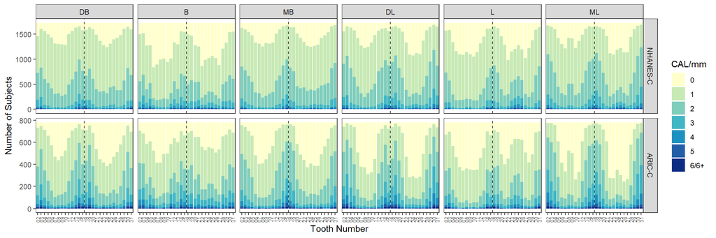

```r
# Number of PD >=5 and CAL >= 4 in teeth
cal_dist <- combined_cohorts %>%
  pivot_longer(cols = starts_with("ohx"),
               names_to = "tooth_id",
               values_to = "value") %>%
  mutate(tooth = str_extract(tooth_id, "\\d\\d"),
         test = str_extract(tooth_id, "pc|la"),
         site = str_extract(tooth_id, "[dspaml]$")) %>%
  mutate(site = case_match(site, "d" ~ "DB" , "s" ~ "MB", "m" ~ "B",
                           "p" ~ "DL", "a" ~ "ML", "l" ~ "L"),
         site = factor(site, levels = c("DB", "B", "MB", "DL", "L", "ML"))) %>%
  mutate(from = factor(case_match(from, "NHANES" ~ "NHANES-C", "ARIC"~"ARIC-C",
                                  "ORIGINS" ~ "ORIGINS-C"),
                       levels = c("NHANES-C", "ARIC-C", "ORIGINS-C"))) %>%
  filter(test == "la") %>%
  ggplot(aes(x = tooth, fill = value)) +
  geom_bar(color = NA, position = position_stack(reverse = FALSE)) +
  geom_vline(xintercept = length(all_tooth)/2+0.5,
             color = "grey20", linetype = "dashed") +
  facet_grid(from~site, scales = "free_y") +
  theme_bw() +
  scale_fill_brewer(name = "CAL/mm", palette = "YlGnBu") +
  labs(x = "Tooth Number", y = "Number of Subjects") +
  theme(axis.text.x = element_text(angle = 90, vjust = 0.5, hjust=1, size = 6),
                      #element_text(angle = 45, vjust = 1, hjust=1, size = 6),
        panel.grid = element_blank())
ggsave(plot = cal_dist, filename = "../res/cal_dist.jpeg",
       width = 12, height = ifelse(enable_origins, 6, 4))
ggsave(plot = cal_dist, filename = "../res/cal_dist.pdf",
       width = 12, height = ifelse(enable_origins, 6, 4))
cal_dist
```

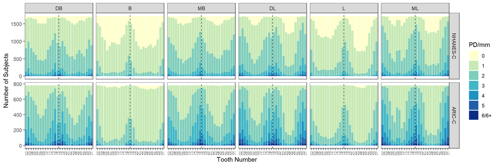

```r
pd_dist <- combined_cohorts %>%
  pivot_longer(cols = starts_with("ohx"),
               names_to = "tooth_id",
               values_to = "value") %>%
  mutate(tooth = str_extract(tooth_id, "\\d\\d"),
         test = str_extract(tooth_id, "pc|la"),
         site = str_extract(tooth_id, "[dspaml]$")) %>%
  mutate(site = case_match(site, "d" ~ "DB" , "s" ~ "MB", "m" ~ "B",
                           "p" ~ "DL", "a" ~ "ML", "l" ~ "L"),
         site = factor(site, levels = c("DB", "B", "MB", "DL", "L", "ML"))) %>%
  mutate(from = factor(case_match(from, "NHANES" ~ "NHANES-C", "ARIC"~"ARIC-C",
                                  "ORIGINS" ~ "ORIGINS-C"),
                       levels = c("NHANES-C", "ARIC-C", "ORIGINS-C"))) %>%
  filter(test == "pc") %>%
  ggplot(aes(x = tooth, fill = value)) +
  geom_bar(color = NA, position = position_stack(reverse = FALSE)) +
  geom_vline(xintercept = length(all_tooth)/2+0.5,
             color = "grey20", linetype = "dashed") +
  facet_grid(from~site, scales = "free_y") +
  theme_bw() +
  scale_fill_brewer(name = "PD/mm", palette = "YlGnBu") +
  labs(x = "Tooth Number", y = "Number of Subjects") +
  theme(axis.text.x = element_text(angle = 90, vjust = 0.5, hjust=1, size = 6),
                      #element_text(angle = 45, vjust = 1, hjust=1, size = 6),
        panel.grid = element_blank())
ggsave(plot = pd_dist, filename = "../res/pd_dist.jpeg",
       width = 12, height = ifelse(enable_origins, 6, 4))
ggsave(plot = pd_dist, filename = "../res/pd_dist.pdf",
       width = 12, height = ifelse(enable_origins, 6, 4))
pd_dist
```

## Evolutionary Algorithm and Best Tooth Combinations

(Calculated using high-performance computing resources.)

```r
##############################
#Find a best n-tooth combination for enhanced partial-mouth diagnosis based on
# a machine-learning classifier using evolutionary algorithm.
##############################
find_row_index <- function(record, mat) { # check if record has appeared in the mat
  idx <- which(apply(mat, 1, function(row) all(row == record)))
  if (length(idx) > 0) return(idx[1]) else return(0)
}

workdir = "/home/guanwh/zhan7474/dental_health"
Date = "0621" # for version control
n.cores = 100
nboot = 1 # number of random splits to evaluate
#train_prop = 0.7 # 70-30 split. Not used. The model parameters in a generative classifier have been pre-specified. So, no random split required.
n_teeth = 6 # a 6-tooth-combination

library(tidyverse)
library(parallel)
library(ordinalNet)
set.seed(seed= 1233455)
setwd(workdir)
source(str_glue("{workdir}/src/case_def.R"))
source(str_glue("{workdir}/src/predict.gen.dependencies.R"))
source(str_glue("{workdir}/src/predict.gen.R"))
source(str_glue("{workdir}/src/calculate_metrics2.R"))

prefix = "ohx"
suffix = c(str_c("pc", c("d", "m", "s", "p", "l", "a"), sep = ""),
           str_c("la", c("d", "m", "s", "p", "l", "a"), sep = "")) # pcd, ..., lad, ...
all_tooth <- sprintf("%02d", c(seq(2,15), seq(18,31))) # all teeth in NHANES
all_ohx <- str_c(prefix,
                 rep(all_tooth, each = length(suffix)),
                 rep(suffix, times = length(all_tooth)))
training_data_raw <- readRDS(str_glue("{workdir}/res/nhanes_complete.rds"))
training_data <- training_data_raw %>%
  mutate(across(.cols = starts_with("ohx"),
                .fns = \(x) case_match(x, "0"~0, "1"~1, "2"~2, "3"~3,
                                       "4"~4, "5"~5, "6/6+"~6))) %>%
  column_to_rownames(var = "seqn") %>%
  select(starts_with("ohx")) %>%
  as.matrix()
#rand_index <- sapply(X = 1:nboot,
#                     FUN = \(x) return(sample.int(
#                       n = nrow(training_data),
#                       size = round(train_prop * nrow(training_data)),
#                       replace = FALSE, prob = NULL, useHash = FALSE)))

mtrcs = c("Prevalence", "AUC", "Sensitivity","Specificity", "F1-score",
          "Diagnostic Odds Ratio")
cal_mdl <- readRDS(str_glue("{workdir}/res/nhanes_cal_genmdl_ord.rds"))
ppd_mdl <- readRDS(str_glue("{workdir}/res/nhanes_ppd_genmdl_ord.rds"))
# well, these model were trained on the whole NHANES dataset, so there can be some data leakage issue here.
# But that should be no problem because we wants to find the best tooth combinations in the whole NHANES dataset
# using these models. The random split was just to introduce some randomness to avoid EA falling into some
# regional maxima.

# parameters for evolutionary algorithm
total_n_nodes = 100 # population size, n of tooth combinations to be evaluated
top_n_nodes = 20 # elite offspring, n of highest AUC tooth combinations to
mutate_rate = 0.2 # proportion of combinations that have a mutation
n_mutation = 1 # n_mutation tooth different
recombination_rate = 0.5 # the ratio of (different) teeth selected from one parent combination

max_steps = 50
top_mean_auc_vec = 0 # this is to track the changes in mean AUC of top nodes, so as to stop the iterations
thresholds <- c(2, 5) # convergence criterion, two decreases in the last five observations
stationary_steps = 3 # after the evolutionary algorithm becomes stationary, continue search around the optimal combination for some iterations

solutions <- matrix(data = "", ncol = n_teeth, nrow = total_n_nodes,
                    dimnames = list(NULL, paste("V", 1:n_teeth, sep = "")))
solution_aucs <- rep(0, total_n_nodes)
all_solutions <- tibble(
  as_tibble(solutions)[0, ],
  auc = numeric()) # record all the evaluations during the search.
# This can be use to track Because we are searching in a non-deterministic environment, this will increase the sample size and get better ranks and evaluations for the final results
total_searches_ea <- 0
stationary_count = 0

for(kkkk in 1:total_n_nodes){
  current_node = sort(sample(all_tooth, n_teeth, replace = FALSE))
  cat("Current node:", current_node, "\n")
  partial_mouth <- str_c(prefix,
                         rep(current_node, each = length(suffix)),
                         rep(suffix, times = length(current_node)))
  res <-
    predict.gen(cal_mdl = cal_mdl, ppd_mdl = ppd_mdl, new_data = training_data,
                input_teeth = partial_mouth, n_cores = n.cores, type ="results")
  metrics_vec <-
    calculate_metrics2(truth = training_data_raw[["MS"]]*1,
                       pred = res$pred_MS, metrics = mtrcs,
                       threshold = "auto")
  current_auc <- metrics_vec["AUC"]
  # current_auc <-
  #   sapply(X = 1:nboot, simplify = TRUE,
  #          FUN = function(bbbb){
  #            # rand_ind <- sample(1:nrow(training_data), replace = TRUE)
  #            # train_temp <- training_data[rand_ind,]
  #            res <-
  #              predict.gen(cal_mdl = cal_mdl, ppd_mdl = ppd_mdl, new_data = training_data,
  #                          input_teeth = partial_mouth, n_cores = n.cores, type ="results")
  #            metrics_vec <-
  #              calculate_metrics2(truth = training_data_raw[["MS"]]*1,
  #                                 pred = res$pred_MS, metrics = mtrcs,
  #                                 threshold = "auto")
  #            return(metrics_vec["AUC"])
  #          })
  # current_auc <- mean(current_auc)
  cat("Current auc:", round(current_auc,4), "\n")
  solutions[kkkk,]<- current_node
  solution_aucs[kkkk] <- current_auc
}
solutions_dup <- duplicated.matrix(solutions, MARGIN = 1)
solutions <- solutions[!solutions_dup,]
solution_aucs <- solution_aucs[!solutions_dup]
solutions_order <- order(solution_aucs, decreasing = TRUE)
solutions <- solutions[solutions_order,]
solution_aucs <- solution_aucs[solutions_order]
all_solutions <- bind_rows(
  all_solutions,
  tibble(as_tibble(solutions), auc = solution_aucs)
)
cat("Current average AUCs for all solutions:",
    round(mean(solution_aucs), 4), "\n")
cat("Current average AUCs for top solutions:",
    round(mean(solution_aucs[1:top_n_nodes]), 4), "\n")
top_mean_auc_vec <- c(mean(solution_aucs[1:top_n_nodes]), top_mean_auc_vec)
total_searches_ea = total_searches_ea+total_n_nodes
```

```r
for(ssss in 1:max_steps){
  parents <- solutions[1:top_n_nodes, ]
  fold <- 2 # increase the size, some recombined solutions after mutation can be still duplicated
  parent1 <- asplit(parents[sample.int(n = top_n_nodes,
                                       size = fold*total_n_nodes,
                                       replace = TRUE),], MARGIN = 1)
  parent2 <- asplit(parents[sample.int(n = top_n_nodes,
                                       size = fold*total_n_nodes,
                                       replace = TRUE),], MARGIN = 1)
  common_tooth <- mapply(FUN = base::intersect, SIMPLIFY = FALSE,
                         parent1, parent2)
  n_common_tooth <- lengths(common_tooth)
  n_choose1 <- floor((n_teeth - n_common_tooth)*recombination_rate)
  n_choose2 <- n_teeth - n_common_tooth - n_choose1
  #it may choose 1 tooth less from parent1,
  #but it does not matter because 1&2 are exchangeable
  distinct_tooth1 <- mapply(FUN = base::setdiff, SIMPLIFY = FALSE,
                            parent1, parent2)
  tooth_from1 <- mapply(FUN = sample, SIMPLIFY = FALSE,
                        distinct_tooth1, n_choose1)
  distinct_tooth2 <- mapply(FUN = base::setdiff, SIMPLIFY = FALSE,
                            parent2, parent1)
  tooth_from2 <- mapply(FUN = sample, SIMPLIFY = FALSE,
                        distinct_tooth2, n_choose2)
  # recombination
  nodes_to_search <- mapply(FUN = c, SIMPLIFY = FALSE,
                            common_tooth, tooth_from1, tooth_from2)
  # to matrix
  nodes_to_search <- matrix(unlist(nodes_to_search), byrow=TRUE,
                            nrow = length(nodes_to_search))
  # mutation
  for(ind in sample.int(fold*total_n_nodes, mutate_rate*fold*total_n_nodes))
    nodes_to_search[ind, sample.int(6, size = n_mutation)] <-
    sample(setdiff(all_tooth, nodes_to_search[ind, ]), size = n_mutation)
  # order, add parents back, and remove duplicates
  # if we are searching in a deterministic environment, we dont need the evaluate
  # the nodes we have visited. Can create a table to prevent this.
  nodes_to_search <- t(apply(X = nodes_to_search, MARGIN = 1,
                             simplify = TRUE, FUN = sort, decreasing = FALSE))
  nodes_to_search <- rbind(parents, nodes_to_search)
  nodes_to_search <- unique.matrix(nodes_to_search)
  if(nrow(nodes_to_search) < total_n_nodes){
    cat(str_glue("Rows in nodes_to_search = {nrow(nodes_to_search)} is smaller than total_n_nodes = {total_n_nodes}. May require to increase fold (currently {fold})"))
  } else{
    nodes_to_search <- nodes_to_search[1:total_n_nodes, ]
  }

  aucs <- rep(0, nrow(nodes_to_search))
  for(rrrr in 1:nrow(nodes_to_search)){
    node <- nodes_to_search[rrrr, ]
    cat("Current node:", node, "\n")
    existed_node <- find_row_index(record = node,
                                   mat = as.matrix(select(all_solutions, V1:V6)))
    # if(existed_node > 0) { # search in an uncertain environment
    if(FALSE){
      current_auc <- all_solutions[["auc"]][existed_node]
      cat("Current auc (skipped):", round(current_auc,4), "\n")
    } else {
      partial_mouth <- str_c(prefix,
                             rep(node, each = length(suffix)),
                             rep(suffix, times = length(node)))
      res <-
        predict.gen(cal_mdl = cal_mdl, ppd_mdl = ppd_mdl, new_data = training_data,
                    input_teeth = partial_mouth, n_cores = n.cores, type ="results")
      metrics_vec <-
        calculate_metrics2(truth = training_data_raw[["MS"]]*1,
                           pred = res$pred_MS, metrics = mtrcs,
                           threshold = "auto")
      current_auc <- metrics_vec["AUC"]
      cat("Current auc:", round(current_auc,4), "\n")
    }
    aucs[rrrr] <- current_auc
  }
  total_searches_ea = total_searches_ea+nrow(nodes_to_search)

  solutions <- nodes_to_search
  solution_aucs <- aucs
  solutions_order <- order(solution_aucs, decreasing = TRUE)
  solutions <- solutions[solutions_order,]
  solution_aucs <- solution_aucs[solutions_order]
  if(ssss == 1){
    print("Solutions:")
    print(solutions)
    print("Solution AUCs:")
    print(solution_aucs)
  }
  all_solutions <- bind_rows(
    all_solutions,
    tibble(as_tibble(solutions), auc = solution_aucs)
  )
  cat("Current average AUCs for all solutions:",
      round(mean(solution_aucs), 4), "\n")
  cat("Current average AUCs for top solutions:",
      round(mean(solution_aucs[1:top_n_nodes]), 4), "\n")
  top_mean_auc_vec <- c(mean(solution_aucs[1:top_n_nodes]), top_mean_auc_vec)
  if(stationary_count == 0){
    if(length(top_mean_auc_vec) >= thresholds[2])
      if(sum(top_mean_auc_vec[1:(thresholds[2]-1)] -
             top_mean_auc_vec[2:thresholds[2]] <= 0) >= thresholds[1]){
        cat("Evolutionary algorithm converges!\n")
        stationary_count <- 1
      }
  } else {# stationary_count >= 1
    stationary_count = stationary_count + 1
    if(stationary_count >= stationary_steps){
      break # break the ssss loop
    }
  }
}
# results
save.image(file = str_glue("{workdir}/res/EA_{Date}.RData"))
saveRDS(object = all_solutions, file = str_glue("{workdir}/res/EA_record_{Date}.rds"))
saveRDS(object = top_n_nodes, file = str_glue("{workdir}/res/EA_ntop_{Date}.rds"))

cat("Total searched tooth combinations for EA:", total_searches_ea, "\n")
solutions <- all_solutions %>%
  group_by(V1, V2, V3, V4, V5, V6) %>%
  summarise(repeated_n=n(), ave_auc= mean(auc)) %>%
  ungroup() %>%
  arrange(desc(ave_auc)) %>%
  rowwise() %>%
  mutate(regimen = str_c(V1, V2, V3, V4, V5, V6, collapse = "")) %>%
  ungroup()
print(solutions, n=top_n_nodes)
saveRDS(object = solutions, file = str_glue("{workdir}/res/EA_solutions_{Date}.rds"))

# recalculate the aucs of the top solutions
# see EA_0621_recal.R
```

### Which tooth are more likely to be selected in top 6-tooth combinations by EA?

```r
n_top = 20
n_teeth = 6
fp_1 = c("GenClassifier" = "EA_", "RandomForest" = "EA_rf_", "SimplePME" = "EA_naive_")
fp_2 = c("GenClassifier" = "_0621", "RandomForest" = "_0722", "SimplePME" = "_0805")
tooth_freq = list("GenClassifier" = character(0),
                  "RandomForest" = character(0),
                  "SimplePME" = character(0))
Methods = c("SimplePME", "GenClassifier", "RandomForest")

for(meth in Methods){
  aucres <- readRDS(str_glue("../res/{fp_1[meth]}aucvec{fp_2[meth]}.rds"))
  stopifnot(n_top == readRDS(str_glue("../res/{fp_1[meth]}ntop{fp_2[meth]}.rds")))
  auctop <- sort(aucres, decreasing = TRUE)[1:n_top]
  tooth_freq[[meth]] <- c(sapply(X = names(auctop), FUN = str_sub,
                                 start = (1:n_teeth)*2-1,
                                 end = (1:n_teeth)*2))
}
tooth_solution_freq <- as.data.frame(tooth_freq) %>%
  pivot_longer(cols = all_of(Methods), names_to = "Methods",
               values_to = "Tooth Number") %>%
  mutate(`Tooth Number` = factor(`Tooth Number`, levels = all_tooth)) %>%
  count(Methods, `Tooth Number`, .drop = FALSE) %>%
  pivot_wider(names_from = `Tooth Number`, values_from = n) %>%
  column_to_rownames(var = "Methods") %>%
  as.matrix()
tooth_solution_freq
```

```
##               02 03 04 05 06 07 08 09 10 11 12 13 14 15 18 19 20 21 22 23 24 25
## GenClassifier  3 20  0  0  0  0  2  0  0  0  0  0  9 13 14 12  0  0  0  0  3 13
## RandomForest   1 20  1  0  0  1  2  0  0  0  0  0 17  7 18  3  0  3  0  3  5 14
## SimplePME     14  4  0  0  0  0  0  0  0  0  1  0 20 20 18  2  1  0  1  1  2  4
##               26 27 28 29 30 31
## GenClassifier  4  0  1  0 17  9
## RandomForest   0  1  0  0  5 19
## SimplePME      2  1  1  0  8 20
```

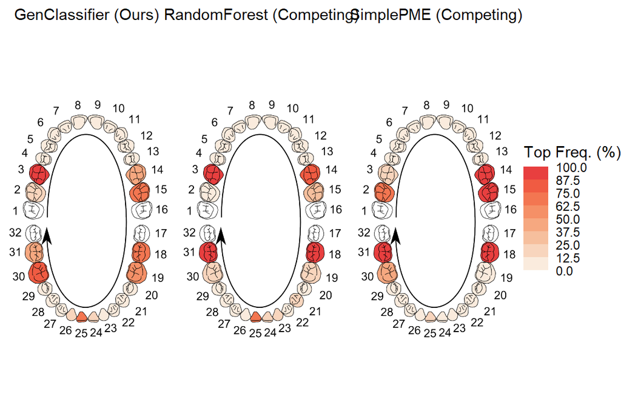

```r
rownames(tooth_solution_freq) <-
  case_match(rownames(tooth_solution_freq),
             "GenClassifier" ~ "GenClassifier (Ours)",
             "RandomForest" ~ "RandomForest (Competing)",
             "SimplePME" ~ "SimplePME (Competing)")
tooth_solution_freq_fig <-
  plot_tooth_heatmap(values = tooth_solution_freq/n_top*100,
                     n_colors = 8,
                     output_svg = "../res/tooth_solution_freq.svg",
                     legend_title = "Top Freq. (%)")
grid::grid.draw(tooth_solution_freq_fig)
```

```r
ggsave(plot = tooth_solution_freq_fig,
       filename = "../res/tooth_solution_freq.jpeg",
       width = 8, height = 2.5)
ggsave(plot = tooth_solution_freq_fig,
       filename = "../res/tooth_solution_freq.pdf",
       width = 8, height = 2.5)
```

### Which 6-tooth combinations are selected by EA for the generative classifier?

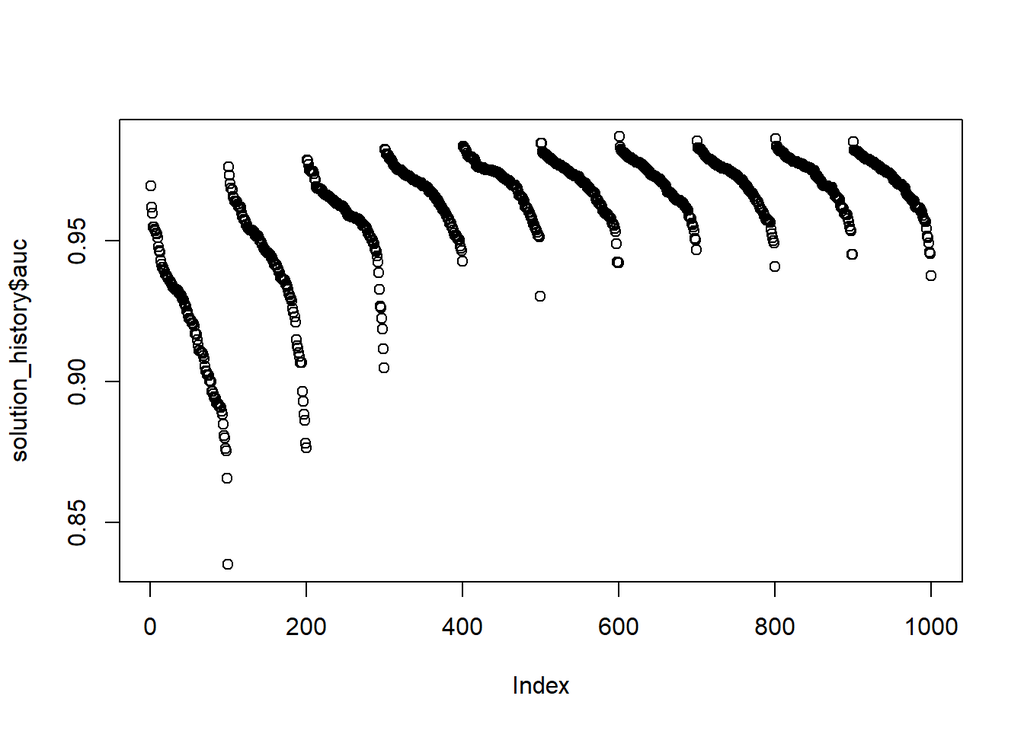

```r
DD = "0621"
n_top_solutions <- readRDS(str_glue("../res/EA_ntop_{DD}.rds")) # how many top solutions to show. It may be better to use the number of "elites" during EA
solution_history <- readRDS(str_glue("../res/EA_record_{DD}.rds"))
plot(solution_history$auc) # good
```

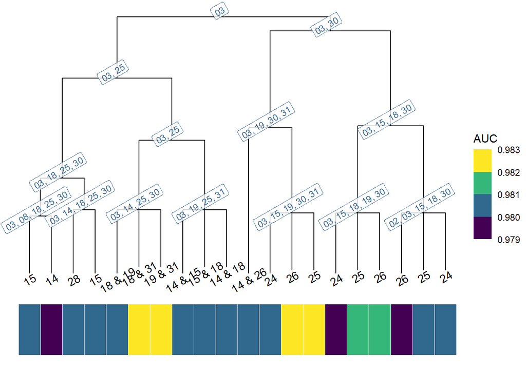

```r
aucvec <- readRDS(str_glue("../res/EA_aucvec_{DD}.rds")) # aucs of all re-evaluated final solutions (~100)
senvec <- readRDS(str_glue("../res/EA_senvec_{DD}.rds"))
# solutions <- readRDS(str_glue("../res/EA_solutions_{DD}.rds")) # raw solutions from EA. Not used. use the re-calculated AUCs
# solutions <- as.data.frame(aucvec) %>%
#   rownames_to_column("regimen") %>%
#   left_join(x = ., y = solutions)
# solutions %>%
#   drop_na() %>%
#   ggplot(aes(x = ave_auc, y = aucvec, color = repeated_n)) +
#   geom_point() +
#   geom_abline(intercept = 0, slope = 1, color = "firebrick") +
#   geom_hline(yintercept = sort(solutions$aucvec, decreasing = TRUE)[n_top_solutions],
#              color = c("green4"))+
#   geom_vline(xintercept = sort(solutions$ave_auc, decreasing = TRUE)[n_top_solutions],
#              color = c("royalblue3"))+
#   geom_vline(xintercept = sort(solutions$ave_auc, decreasing = TRUE)[50],
#              color = c("purple"))+
#   labs(x = "Raw EA AUCs", y = "Re-Calculated AUCs") +
#   scale_colour_viridis_b(option = "inferno", direction = -1,
#                          name = "EA Visited Times") +
#   theme_bw()
# to get an accurate estimate of AUC, re-calculation is required
# 14 solutions are common top-20 solutions
# recalculate the top 50 solutions can largely cover the true top 20 solutions

aucvec_top <- sort(aucvec, decreasing = TRUE)[1:n_top_solutions]
n_teeth <- nchar(names(aucvec)[1])/2
num.molar <- \(teeth){
  return(sum(teeth %in% c("02", "03", "14", "15", "18", "19", "30", "31")))
}
num.lower <- \(teeth){
  return(sum( as.integer(teeth)>=18 & as.integer(teeth)<=31 ))
}

solutions <- as.data.frame(aucvec_top) %>%
  rownames_to_column(var = "ID") %>%
  rename("auc" = "aucvec_top") %>%
  mutate(senstivity = senvec[ID]) %>%
  separate_wider_position(cols = ID, cols_remove = FALSE,
                          width = setNames(rep(2,n_teeth),
                                           paste("V",1:n_teeth,sep =""))) %>%
  rowwise()%>%
  mutate(num_molars = num.molar(c_across(starts_with("V"))),
         num_lowers = num.lower(c_across(starts_with("V")))) %>%
  ungroup()

# calculate the dist and do a clustering
# dist = # of different teeth
solutions_dist <- matrix(0, nrow = nrow(solutions), ncol = nrow(solutions),
                         dimnames = list(solutions$ID, solutions$ID))
for(i in 1:(nrow(solutions)-1))
  for(j in (i+1):nrow(solutions)){
    common_teeths <- intersect(unlist(solutions[i, paste("V",1:n_teeth,sep ="")]),
                               unlist(solutions[j, paste("V",1:n_teeth,sep ="")]))
    diss_ij = n_teeth - length(common_teeths)
    if(diss_ij == 1){
      tooth_1 <- setdiff(unlist(solutions[i, paste("V",1:n_teeth,sep ="")]),
                         unlist(solutions[j, paste("V",1:n_teeth,sep ="")]))
      tooth_2 <- setdiff(unlist(solutions[j, paste("V",1:n_teeth,sep ="")]),
                         unlist(solutions[i, paste("V",1:n_teeth,sep ="")]))
      if(abs(as.numeric(tooth_1) - as.numeric(tooth_2)) == 1) # adjacent
        diss_ij = diss_ij - 0.05 # this will violate the distance axioms
    }
    solutions_dist[i, j] <- solutions_dist[j, i] <- diss_ij
  }
solutions_dist <- as.dist(solutions_dist)


# create a tree
solutions_cluster <- solutions_dist %>%
  hclust(., method = "average") %>%
  ape::as.phylo() %>%
  ape::di2multi()
# collapse very close nodes (for a better plot!)
solutions_cluster$edge.length <-
  if_else(solutions_cluster$edge.length > 0.05,
          solutions_cluster$edge.length, 0)
solutions_cluster <- ape::di2multi(solutions_cluster)
# add node labels
solutions_cluster$node.label <-
  sapply(X = 1:ape::Nnode(solutions_cluster), simplify = TRUE,
       FUN = function(node_id){
         node_id = node_id + ape::Ntip(solutions_cluster)
         tip_ids <- phytools::getDescendants(solutions_cluster, node = node_id)
         tip_ids <- tip_ids[tip_ids <= ape::Ntip(solutions_cluster)]
         tip_labels <- solutions_cluster$tip.label[tip_ids]
         tooth_occurrence <-
           c(sapply(tip_labels, FUN = substring,
                    first = seq(1, 6*2, by = 2), last = seq(1, 6*2, by = 2)+1))
         tooth_occurrence <- plyr::count(tooth_occurrence)
         shared_tooth <- tooth_occurrence$x[tooth_occurrence$freq == length(tip_labels)]
         return(paste(sort(shared_tooth), collapse = ", "))
       })
# reduce the end edge length (for better plots!)
tip_edge_index <- solutions_cluster$edge[,2] <= ape::Ntip(solutions_cluster)
solutions_cluster$edge.length[tip_edge_index] <-
  solutions_cluster$edge.length[tip_edge_index] - 0.25
# edit the tip labels so that they only show the difference from the nearest node
solutions_cluster$short_label <-
  sapply(X = 1:ape::Ntip(solutions_cluster), simplify = TRUE,
       FUN = function(tip_id){
         parent_node <- phytools::getParent(solutions_cluster, node = tip_id) # the nearest parent
         parent_node_id <- parent_node - ape::Ntip(solutions_cluster)
         parent_node_label <- solutions_cluster$node.label[parent_node_id]
         parent_solution <- str_split_1(parent_node_label, pattern = ", ")
         tip_label <- solutions_cluster$tip.label[tip_id]
         tip_solution <- str_sub(tip_label, start = (1:6)*2-1, end = (1:6)*2)
         tip_label_diff <- setdiff(tip_solution, parent_solution)
         return(paste(sort(tip_label_diff), collapse = " & "))
       })


# plot
solutions_cluster_fig <- ggtree(solutions_cluster, layout = "dendrogram") +
  geom_tiplab(mapping = aes(label=c(solutions_cluster$short_label,
                                    solutions_cluster$node.label)),
              offset = -0.02, angle = 30, hjust = 0.5) +
  # some comments here:
  # the tip labels are arranged in the the original order (as in `solutions`)
  # the tip labels also correspond to the tip id (1-20)
  # but tips are not arranged in the order of tip labels in the plot
  # that means they have different aes(x, y) settings from tip ids
  # the node labels here will not be used in geom_tiplab()
  # the node labels extend `mapping` vector to 38 elements
  # the short_label should correspond to tip labels
  # the short_label will inherit (x, y) directly from the tree
  geom_nodelab(geom = "label", vjust =-0.2, hjust = 0.5,
               color= "steelblue4", size = 3, alpha = 0.8,
               angle= 30)
solutions_cluster_annotation <- solutions %>%
  column_to_rownames("ID") %>%
  select(auc) %>%
  rename(AUC = "auc")
# another comment:
# gheatmap creates a heatmap according to rownames of annotation data and tip labels
# therefore, while we can show duplicated tip labels, we can not assign correct values
# in the heatmaps to multiple tips with the same tip labels.
# create a short_label will be a better solution
solutions_cluster_fig <- gheatmap(p = solutions_cluster_fig, colnames = FALSE,
                                  data = solutions_cluster_annotation,
                                  width = 0.2, offset = 0.02) +
  scale_fill_binned(name = "AUC",type = "viridis",
                    breaks = seq(floor(min(aucvec_top)*1000)/1000,
                                 ceiling(max(aucvec_top)*1000)/1000,
                                 by = 0.001),
                    limits = c(floor(min(aucvec_top)*1000)/1000,
                               ceiling(max(aucvec_top)*1000)/1000)) +
  theme(plot.margin = unit(c(0, 0, 0, 15), "pt"))
print(solutions_cluster_fig)
```

```r
ggsave(plot = solutions_cluster_fig, filename = "../res/solutions_dendro.jpeg",
       width = 8, height = 4)
ggsave(plot = solutions_cluster_fig, filename = "../res/solutions_dendro.pdf",
       width = 8, height = 4)
```

### The best 6-tooth combination and its family members (4- to 14-tooth combinations)

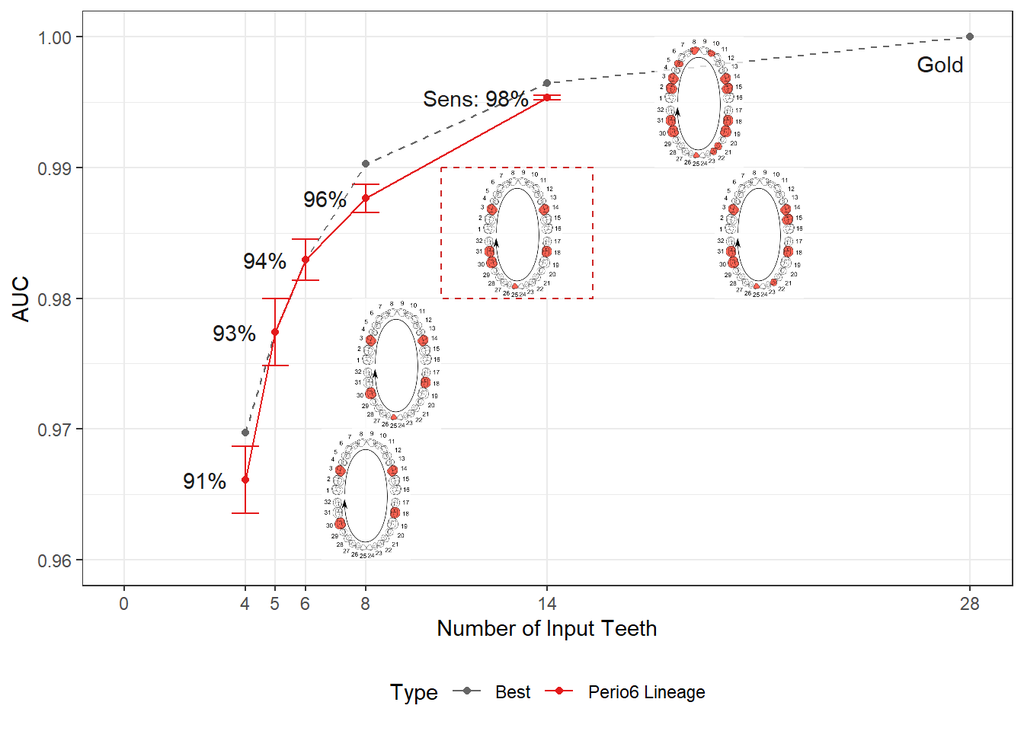

```r
n_top = 20
n_teeths = c("0714" = 14, "0713" = 8, "0621" = 6, "0711" = 5, "0712" = 4)
tooth_combination = c("03", "14", "18", "25", "30", "31")
# tooth_combination = c("03", "08", "15", "18", "19", "25", "30", "31")
num.molar <- \(teeth){
  return(sum(teeth %in% c("02", "03", "14", "15", "18", "19", "30", "31")))
}
num.lower <- \(teeth){
  return(sum( as.integer(teeth)>=18 & as.integer(teeth)<=31 ))
}
family.of.selected <- \(t_c, best_tc = c("03", "14", "18", "25", "30", "31")){
  return(length(intersect(t_c, best_tc)) == min(length(best_tc), length(t_c)))
}

solution_tot<- tibble(ID = character(), n_teeth = numeric(),
                      auc = numeric(), sd = numeric(), senstivity = numeric(),
                      num_molars = numeric(), num_lowers = numeric(),
                      selected_family = logical())
for(iiii in 1:length(n_teeths)){
  n_teeth <- n_teeths[iiii]
  aucres <- readRDS(str_glue("../res/EA_aucvec_{names(n_teeths)[iiii]}.rds"))
  senres <- readRDS(str_glue("../res/EA_senvec_{names(n_teeths)[iiii]}.rds"))
  aucsd <- readRDS(str_glue("../res/EA_aucsd_{names(n_teeths)[iiii]}.rds"))

  stopifnot(n_top == readRDS(str_glue("../res/EA_ntop_{names(n_teeths)[iiii]}.rds")))

  aucvec_top <- sort(aucres, decreasing = TRUE)[1:n_top]

  solutions <- as.data.frame(aucvec_top) %>%
    rownames_to_column(var = "ID") %>%
    rename("auc" = "aucvec_top") %>%
    mutate(senstivity = senres[ID],
           sd = aucsd[ID]) %>%
    separate_wider_position(cols = ID, cols_remove = FALSE,
                            width = setNames(rep(2,n_teeth),
                                             paste("V",1:n_teeth,sep =""))) %>%
    rowwise()%>%
    mutate(num_molars = num.molar(c_across(starts_with("V"))),
           num_lowers = num.lower(c_across(starts_with("V"))),
           selected_family = family.of.selected(c_across(starts_with("V")),
                                                tooth_combination)) %>%
    # family.of.selected can only compare two combinations if one contains
    # the other. In our case, we are actually comparing across 5 combinations
    # more complicated.
    # (but it works <just in this case.>)
    ungroup()%>%
    mutate(n_teeth = n_teeth, rank = n_top - rank(auc) + 1) %>% # the highest rank, the highest AUC
    select(-starts_with("V"))
  solution_tot <- bind_rows(solution_tot, solutions)
}
solution_tot <- solution_tot %>%
  group_by(n_teeth, selected_family) %>%
  slice_max(order_by = auc, n = 1) %>%
  mutate(note =
           if_else(n_teeth == 14,
                   str_glue("Sens: {round(senstivity*100, 0)}%"),
                   str_glue("{round(senstivity*100, 0)}%"))) %>%
  bind_rows(.,
            tibble(n_teeth = 28, auc = 1, sd = 0, senstivity = 1,
                   selected_family = FALSE, rank = 1, note = NA))

solution_family_fig <-
  bind_rows(solution_tot %>% filter(rank == 1) %>% mutate(type = "Best", note = NA),
            solution_tot %>% filter(selected_family) %>% mutate(type = "Perio6 Lineage")) %>%
  mutate(type = factor(type, levels = c("Best", "Perio6 Lineage"))) %>%
  ggplot(aes(y = auc, x = n_teeth, color = type)) +
  geom_errorbar(data = ~subset(., selected_family), # put at the bottom
                aes(ymin = auc-sd, ymax = auc+sd))+
  geom_point() +
  geom_line(aes(linetype = type, group = type)) +
  geom_text_repel(aes(label = note), nudge_y = 0, nudge_x = -1,
                  color = "grey10", box.padding = 0.5, point.padding = 0.5) +
  # geom_text(data = ~subset(., selected_family), aes(label = note),
  #           color = "grey10", nudge_y = 0, nudge_x = 0,
  #           #angle = 30, #hjust = 1, vjust = 1,
  #           check_overlap = FALSE) +
  scale_color_manual(values = c("grey40", "#e41a1c"), name = "Type")+
  scale_linetype_manual(values = c("dashed", "solid"), name = "Type")+
  scale_x_continuous(name = "Number of Input Teeth",
                     breaks = c(0,unique(solution_tot$n_teeth)),
                     minor_breaks = NULL,
                     limits = c(0,28)) +
  scale_y_continuous(name = "AUC",
                     breaks = seq(0.96, 1, by = 0.01),
                     limits = c(0.96, 1)) +
  annotate("text", x = 27, y = 0.998, label = "Gold", color = "grey10") +
  theme_bw() + guides(color=guide_legend(title="Type")) +
  theme(legend.position="bottom")

# create tooth combination figures
solutions_family <- solution_tot$ID[solution_tot$selected_family]
solutions_family <- solutions_family[!is.na(solutions_family)]
x_min <- c(5   , 6   , 10  , 18  , 16)
y_max <- c(0.97, 0.98, 0.99, 0.99, 1)
#   seq(5, 19, length.out = length(solutions_family))
# x_max <- seq(14, 28, length.out = length(solutions_family))
# y_min <- seq(0.964, 0.994, length.out = length(solutions_family))
# y_max <- seq(0.972, 1.003, length.out = length(solutions_family))
for(iiii in 1:length(solutions_family)){
  tc = solutions_family[iiii]
  n_teeth <- nchar(tc)/2
  t_ids <- str_sub(string = tc, start = (1:n_teeth)*2-1, end = (1:n_teeth)*2)
  output_svg <- str_glue("../res/{tc}.svg")
  y_pos <- filter(solution_tot, ID == tc)[["auc"]]

  paint_tooth(t_ids, colors = rep("#FF6454", length = length(t_ids)),
              output_file = output_svg)
  svg_magick <- magick::image_read(rsvg::rsvg(output_svg, width = 300)) %>% # read back
    magick::image_background("rgba(255,255,255,0.5)") %>% # add a background color to make it not so transparent
    magick::image_flatten()
  solution_family_fig <- solution_family_fig +
    annotation_custom(
      grid::rasterGrob(svg_magick, interpolate = TRUE),
      xmin = x_min[iiii], xmax = x_min[iiii] + 6,  # the scale does not matter. It will be centered at (0,0)
      ymin = y_max[iiii] - 0.01, ymax = y_max[iiii])
  if(n_teeth == 6){
    solution_family_fig <- solution_family_fig +
      annotate(
        "rect",
        xmin = x_min[iiii] + 0.5, xmax = x_min[iiii] + 6 - 0.5,  # the scale does not matter. It will be centered at (0,0)
        ymin = y_max[iiii] - 0.01, ymax = y_max[iiii],
        fill = "NA", color = "firebrick3", linewidth = 0.5, linetype = "dashed")
  }
}
solution_family_fig
```

```r
ggsave(filename = "../res/solution_family_fig.jpeg",
       plot = solution_family_fig, width = 6, height = 6.5)
ggsave(filename = "../res/solution_family_fig.pdf",
       plot = solution_family_fig, width = 6, height = 6.5)
```

### Combined figure for best tooth combination

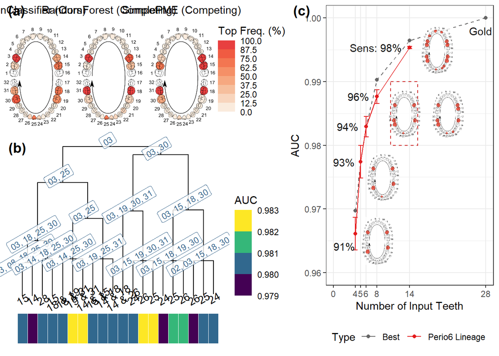

```r
left_column <- plot_grid(
  tooth_solution_freq_fig,
  solutions_cluster_fig,
  ncol = 1,
  rel_heights = c(2.5, 4),
  labels = c("(a)", "(b)")
)
right_column <- plot_grid(solution_family_fig, labels = "(c)")
tooth_selection_comb_fig <- plot_grid(
  left_column,
  right_column,
  rel_widths = c(8, 6)
)
tooth_selection_comb_fig
```

```r
ggsave(filename = "../res/tooth_selection_comb_fig.jpeg",
       plot = tooth_selection_comb_fig, width = 14, height = 6.5)
ggsave(filename = "../res/tooth_selection_comb_fig.pdf",
       plot = tooth_selection_comb_fig, width = 14, height = 6.5)
```

## Spatial correlation between periodontal measures and network analysis

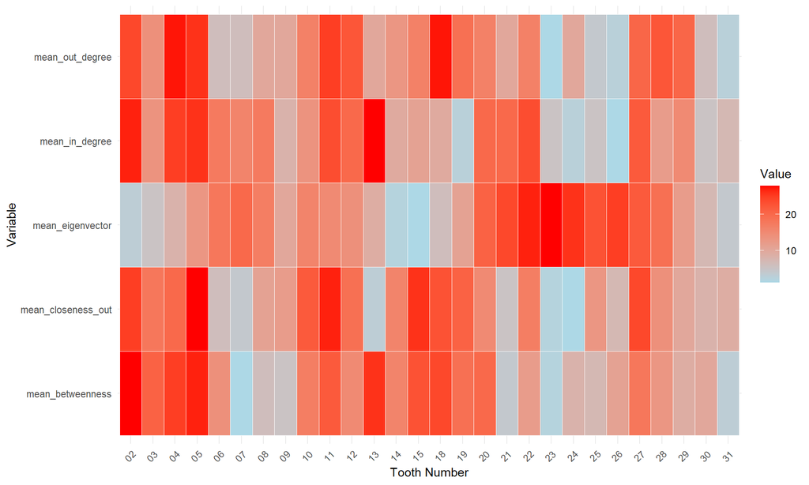

```r
library(igraph)
interested_teeth <- table(tooth_freq[["GenClassifier"]])
interested_teeth <- names(interested_teeth[interested_teeth>5]) #"03" "14" "15" "18" "19" "25" "30" "31"
source(str_glue("../src/get.adjacency.R"))
nhanes_cal_mdl <- readRDS(str_glue("../res/nhanes_cal_genmdl_ord.rds"))
adjacency_mat <- get.adjacency(object = nhanes_cal_mdl,
                               whichLambda = 1) # 1-6, 1 for the least associations with a lambda = 0.025
adjacency_mat <- abs(adjacency_mat)
# interdental sites
adjacency_mat <- adjacency_mat[str_detect(rownames(adjacency_mat), "ohx\\d\\dla[dspc]"),
                               str_detect(colnames(adjacency_mat), "ohx\\d\\dla[dspc]")]
network <- graph_from_adjacency_matrix(adjacency_mat, mode = "directed",
                                       weighted = TRUE, diag = FALSE)

in_degree <- degree(network, mode = "in")
out_degree <- degree(network, mode = "out")
total_degree <- degree(network, mode = "total")
degree_df <- data.frame(
  node = V(network)$name,
  in_degree = in_degree,
  out_degree = out_degree,
  total_degree = total_degree
)

# centrality
betweenness_cent <- betweenness(network, directed = TRUE, normalized = TRUE)
closeness_in <- closeness(network, mode = "in", normalized = TRUE)
closeness_out <- closeness(network, mode = "out", normalized = TRUE)
eigenvector_cent <- eigen_centrality(network, directed = TRUE)$vector
pagerank_cent <- page_rank(network)$vector
hits_scores <- authority_score(network)
authority_cent <- hits_scores$vector
hub_cent <- hub_score(network)$vector
centrality_df <- data.frame(
  node = V(network)$name,
  betweenness = betweenness_cent,
  closeness_in = closeness_in,
  closeness_out = closeness_out,
  eigenvector = eigenvector_cent,
  pagerank = pagerank_cent,
  authority = authority_cent,
  hub = hub_cent
)

# modularity Louvain algorithm
louvain_modules <- cluster_louvain(as.undirected(network))
modules_df <- data.frame(
  node = V(network)$name,
  louvain = membership(louvain_modules)
)

results_df <- merge(degree_df, centrality_df, by = "node")
results_df <- merge(results_df, modules_df, by = "node")
results_df <- results_df %>%
  mutate(tooth_no = str_extract(node, "\\d\\d"),
         site  = str_extract(node, "la[dmspla]"))
tooth_level_df <- results_df %>% group_by(tooth_no) %>%
    summarise(
        mean_out_degree = mean(out_degree),
        mean_in_degree = mean(in_degree),
        mean_betweenness = mean(betweenness),
        mean_closeness_out = mean(closeness_out),
        mean_eigenvector = mean(eigenvector),
        # mean_pagerank = mean(pagerank),
        # mean_authority = mean(authority),
        # mean_hub = mean(hub),
        .groups = 'drop'
    )
tooth_level_df %>%
  mutate(across(starts_with("mean_"), .fns = rank)) %>%
  pivot_longer(
    cols = -tooth_no,
    names_to = "variable",
    values_to = "value"
  ) %>% ggplot(aes(x = tooth_no, y = variable, fill = value)) +
  geom_tile(color = "white") +
  scale_fill_gradient(low = "lightblue", high = "red") +
  theme_minimal() +
  labs(x = "Tooth Number", y = "Variable", fill = "Value") +
  theme(axis.text.x = element_text(angle = 45, hjust = 1))
```

```r
# the results are not very interpretable
# it seems molars have higher degree and betweenness centrality,
#and incisors have higher eigenvector centrality
# however, why two molars of 30 and 31 have so low degree centrality?
# in addition, the centrality measurements seems not to be able to explain
# why the optimal tooth combination
```

## Model Performance Evaluations

### Internal Validation in NHAHES Test Dataset Based on Out-of-fold Predictions

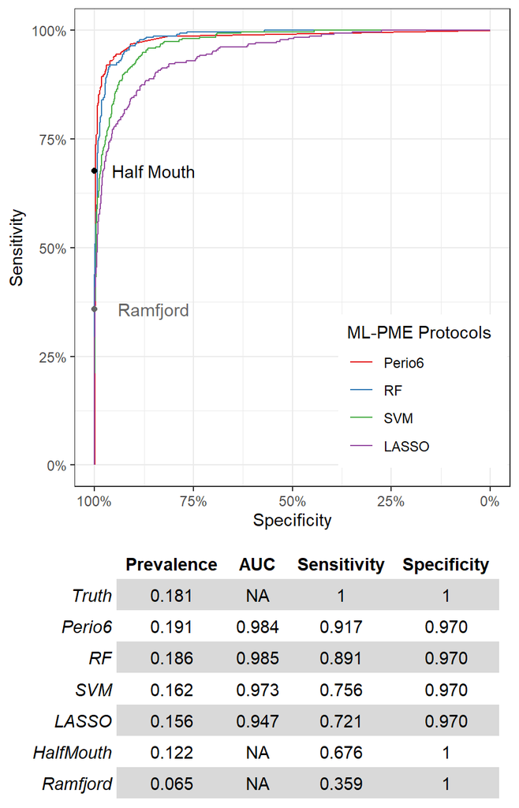

```r
library(ggpubr) # wanted to change to cowplot and flextable. Gave up...
metrics = c("Prevalence", "AUC", "Sensitivity",
            "Specificity", "F1-score", "Diagnostic Odds Ratio")
format_metrics <- function(x) {
  rounded <- round(x, 3)
  ifelse(rounded == floor(rounded),
         sprintf("%.0f", rounded),  # whole numbers without decimals
         sprintf("%.3f", rounded))  # 3 decimal places
}
set.seed(seed = 123456)

train_data <- nhanes_complete %>%
  mutate(across(.cols = starts_with("ohx"),
                .fns = \(x) case_match(x, "0"~0, "1"~1, "2"~2, "3"~3,
                                       "4"~4, "5"~5, "6/6+"~6))) %>%
  select(seqn, starts_with("ohx"), MS) %>%
  as.data.frame()
tc <- c("03", "14", "18", "25", "30", "31")
tc <- str_c(prefix,
            rep(tc, each = length(suffix)),
            rep(suffix, times = length(tc)))
ramfjord_teeth <- str_c(prefix,
                        rep(Ramfjord, each = length(suffix)),
                        rep(suffix, times = length(Ramfjord)))
half_mouth_teeth <- str_c(prefix,
                          rep(half_mouth, each = length(suffix)),
                          rep(suffix, times = length(half_mouth)))
# deterministic classifiers: RF, SVM, penalized regression
ML_competing_tbl <-
  prediction_models(training = train_data,
                    test = NULL,
                    using = tc,
                    outcome = "MS", verbose = FALSE)
# GenClassifier
res <- readRDS(file = "../res/nhanes_6t_set1_rep0.rds")
# simple PMEs
Ramfjord_tbl <-
  prediction_models(training = train_data,
                    test = NULL,
                    using = ramfjord_teeth, method = "naive",
                    outcome = "MS", verbose = FALSE)
Half_tbl <-
  prediction_models(training = train_data,
                    test = NULL,
                    using = half_mouth_teeth, method = "naive",
                    outcome = "MS", verbose = FALSE)

pred_mat <- ML_competing_tbl$pred_mat
pred_mat <- pred_mat %>%
  as.data.frame() %>%
  mutate(Perio6 = res$pred_MS,
         HalfMouth = Half_tbl$pred_mat[, "naive"],
         Ramfjord = Ramfjord_tbl$pred_mat[, "naive"]) %>%
  rename(LASSO = "penalized", RF = "rf", SVM = "svm", Truth = "truth") %>%
  select(Truth, Perio6, RF, SVM, LASSO, HalfMouth, Ramfjord)

metrcs_mat <- matrix(NA, nrow = ncol(pred_mat), ncol = length(metrics) + 1,
                     dimnames = list(names(pred_mat), c(metrics, "Threshold")))
for(varr in colnames(pred_mat)){
  if(varr %in% c("LASSO", "SVM", "RF", "Perio6"))
    threshold  = "auto"
  if(varr == "Perio6") threshold = 0.20 # fixed it at 0.20
  if(varr %in% c("HalfMouth", "Ramfjord", "Truth"))
    threshold = NA_real_
  metrcs_mat[varr, ] <- calculate_metrics2(truth = pred_mat$Truth,
                                           pred = pred_mat[[varr]],
                                           threshold = threshold,
                                           specificity_thre = 0.97)
}


rocobj <- roc(formula = Truth ~ Perio6 + RF + SVM + LASSO,
              data = pred_mat, quiet =TRUE)
roc_figure_nhanes <- ggroc(rocobj)+ theme_bw() +
  annotate("point",
           y = metrcs_mat["Ramfjord", "Sensitivity"],
           x = metrcs_mat["Ramfjord", "Specificity"],
           color = "grey40")+
  annotate("text", label= "Ramfjord",
           y = metrcs_mat["Ramfjord", "Sensitivity"],
           x = metrcs_mat["Ramfjord", "Specificity"] - 0.15,
           color = "grey40")+
  annotate("point",
           y = metrcs_mat["HalfMouth", "Sensitivity"],
           x = metrcs_mat["HalfMouth", "Specificity"],
           color = "black")+
  annotate("text", label= "Half Mouth",
           y = metrcs_mat["HalfMouth", "Sensitivity"],
           x = metrcs_mat["HalfMouth", "Specificity"] - 0.15,
           color = "black")+
  scale_color_brewer(palette = "Set1", direction = 1, name = "ML-PME Protocols")+
  labs(x = "Specificity", y = "Sensitivity")+
  scale_y_continuous(labels = scales::percent) +
  scale_x_reverse(labels = scales::percent) +
  theme(legend.position = c(0.8, 0.2))
temp_mat <- metrcs_mat[,c("Prevalence", "AUC", "Sensitivity", "Specificity")]
rownames(temp_mat) <-
  if_else(rownames(temp_mat) == "GenClassifier", "Perio6", rownames(temp_mat))
temp_mat <- apply(temp_mat, c(1,2), format_metrics)
table_plot_nhanes <- ggtexttable(temp_mat, theme = ttheme("lBlack"))

roc_figure_combined_nhanes <- ggarrange(roc_figure_nhanes, table_plot_nhanes,
                                        ncol = 1, nrow = 2,
                                        heights = c(2, 1))
roc_figure_combined_nhanes
```

```r
ggsave(filename = "../res/nhanes_performance.jpeg",
       plot = roc_figure_combined_nhanes, width = 4.5, height = 7)
ggsave(filename = "../res/nhanes_performance.pdf",
       plot = roc_figure_combined_nhanes, width = 4.5, height = 7)
```

### External Validation in ARIC Dataset (Complete Cases)

```r
test_data <- aric_complete %>%
  mutate(across(.cols = starts_with("ohx"),
                .fns = \(x) case_match(x, "0"~0, "1"~1, "2"~2, "3"~3,
                                       "4"~4, "5"~5, "6/6+"~6))) %>%
  select(seqn, starts_with("ohx"), MS) %>%
  as.data.frame()
# deterministic classifiers: RF, SVM, penalized regression
ML_competing_tbl <-
  prediction_models(training = train_data,
                    test = test_data,
                    using = tc,
                    outcome = "MS", verbose = FALSE)
# GenClassifier
res <- readRDS(file = "../res/aric_6t_set1_rep0.rds")
# simple PMEs
Ramfjord_tbl <-
  prediction_models(training = test_data,
                    test = NULL,
                    using = ramfjord_teeth, method = "naive",
                    outcome = "MS", verbose = FALSE)
Half_tbl <-
  prediction_models(training = test_data,
                    test = NULL,
                    using = half_mouth_teeth, method = "naive",
                    outcome = "MS", verbose = FALSE)

pred_mat <- ML_competing_tbl$pred_mat
pred_mat <- pred_mat %>%
  as.data.frame() %>%
  mutate(Perio6 = res$pred_MS,
         HalfMouth = Half_tbl$pred_mat[, "naive"],
         Ramfjord = Ramfjord_tbl$pred_mat[, "naive"]) %>%
  rename(LASSO = "penalized", RF = "rf", SVM = "svm", Truth = "truth") %>%
  select(Truth, Perio6, RF, SVM, LASSO, HalfMouth, Ramfjord)

metrcs_mat <- matrix(NA, nrow = ncol(pred_mat), ncol = length(metrics) + 1,
                     dimnames = list(names(pred_mat), c(metrics, "Threshold")))
for(varr in colnames(pred_mat)){
  threshold = case_match(varr, "LASSO"~0.42, "SVM" ~ 0.38, "RF"~0.40,
                         "Perio6" ~ 0.20, .default = NA_real_) # using NHANES values
  metrcs_mat[varr, ] <- calculate_metrics2(truth = pred_mat$Truth,
                                           pred = pred_mat[[varr]],
                                           threshold = threshold,
                                           specificity_thre = 0.97)
}


rocobj <- roc(formula = Truth ~ Perio6 + RF + SVM + LASSO,
              data = pred_mat, quiet =TRUE)
roc_figure_aric <- ggroc(rocobj)+ theme_bw() +
  annotate("point",
           y = metrcs_mat["Ramfjord", "Sensitivity"],
           x = metrcs_mat["Ramfjord", "Specificity"],
           color = "grey40")+
  annotate("text", label= "Ramfjord",
           y = metrcs_mat["Ramfjord", "Sensitivity"],
           x = metrcs_mat["Ramfjord", "Specificity"] - 0.15,
           color = "grey40")+
  annotate("point",
           y = metrcs_mat["HalfMouth", "Sensitivity"],
           x = metrcs_mat["HalfMouth", "Specificity"],
           color = "black")+
  annotate("text", label= "Half Mouth",
           y = metrcs_mat["HalfMouth", "Sensitivity"],
           x = metrcs_mat["HalfMouth", "Specificity"] - 0.15,
           color = "black")+
  scale_color_brewer(palette = "Set1", direction = 1, name = "ML-PME Protocols")+
  labs(x = "Specificity", y = "Sensitivity")+
  scale_y_continuous(labels = scales::percent) +
  scale_x_reverse(labels = scales::percent) +
  theme(legend.position = c(0.8, 0.2))
```

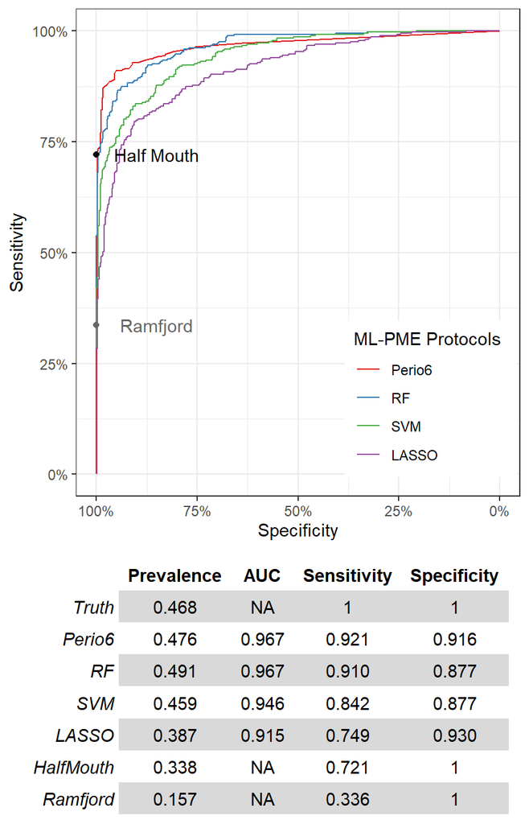

```r
temp_mat <- metrcs_mat[,c("Prevalence", "AUC", "Sensitivity", "Specificity")]
rownames(temp_mat) <-
  if_else(rownames(temp_mat) == "GenClassifier", "Perio6", rownames(temp_mat))
temp_mat <- apply(temp_mat, c(1,2), format_metrics)
table_plot_aric <- ggtexttable(temp_mat, theme = ttheme("lBlack"))

roc_figure_combined_aric <- ggarrange(roc_figure_aric, table_plot_aric,
                                      ncol = 1, nrow = 2,
                                      heights = c(2, 1))
roc_figure_combined_aric
```

```r
ggsave(filename = "../res/aric_performance.jpeg",
       plot = roc_figure_combined_aric, width = 4.5, height = 7)
ggsave(filename = "../res/aric_performance.pdf",
       plot = roc_figure_combined_aric, width = 4.5, height = 7)
```

### External Validation in ARIC Dataset (Robust performance when changing to different tooth combinations)

```r
test_data <- aric_complete %>%
  mutate(across(.cols = starts_with("ohx"),
                .fns = \(x) case_match(x, "0"~0, "1"~1, "2"~2, "3"~3,
                                       "4"~4, "5"~5, "6/6+"~6))) %>%
  select(seqn, starts_with("ohx"), MS) %>%
  as.data.frame()
scenarios <- c("Perio6 Default Teeth\n(03, 14, 18, 25, 30, 31)" = "aric_6t_set1_rep",
               "Alternative 6 Teeth\n(03, 15, 19, 25, 30, 31)" = "aric_6t_set2_rep",
               "Alternative 5 Teeth\n(03, 14, 18, 25, 30)" = "aric_5t_set1_rep")
alter_comb_df <- tibble(tc = character(),
                        AUC = numeric(), AUC_sd = numeric(),
                        Sensitivity = numeric(), Sensitivity_sd = numeric(),
                        Specificity = numeric(), Specificity_sd = numeric())
for(ss in 1:length(scenarios)){
  cat("Current scenario:", names(scenarios)[ss], "\n")
  aucs <- numeric(3)
  sens <- numeric(3)
  spec <- numeric(3)
  for(rr in 1:3){
    res <- readRDS(file = str_glue("../res/{scenarios[ss]}{rr-1}.rds"))
    if(rr == 1) stopifnot(test_data$seqn == res$seqn)
    metrcs_vec <- calculate_metrics2(truth = test_data$MS*1,
                                     pred = res$pred_MS*1,
                                     threshold = 0.20)
    aucs[rr] <- metrcs_vec["AUC"]
    sens[rr] <- metrcs_vec["Sensitivity"]
    spec[rr] <- metrcs_vec["Specificity"]
  }
  cat(str_glue("AUC: {round(mean(aucs),3)} ({round(sd(aucs),3)})"), "\n",
      str_glue("Sensitivity: {round(mean(sens),3)} ({round(sd(sens),3)})"), "\n",
      str_glue("Specificity: {round(mean(spec),3)} ({round(sd(spec),3)})"), "\n")
  alter_comb_df_temp <-
    tibble(tc = names(scenarios)[ss],
           AUC = mean(aucs), AUC_sd = sd(aucs),
           Sensitivity = mean(sens), Sensitivity_sd = sd(sens),
           Specificity = mean(spec), Specificity_sd = sd(spec))
  alter_comb_df <- bind_rows(alter_comb_df, alter_comb_df_temp)
}
```

```
## Current scenario: Perio6 Default Teeth
## (03, 14, 18, 25, 30, 31)
## AUC: 0.966 (0.002)
##  Sensitivity: 0.917 (0.004)
##  Specificity: 0.915 (0.006)
## Current scenario: Alternative 6 Teeth
## (03, 15, 19, 25, 30, 31)
## AUC: 0.965 (0.003)
##  Sensitivity: 0.916 (0.002)
##  Specificity: 0.9 (0.01)
## Current scenario: Alternative 5 Teeth
## (03, 14, 18, 25, 30)
## AUC: 0.958 (0.001)
##  Sensitivity: 0.901 (0.003)
##  Specificity: 0.896 (0.006)
```

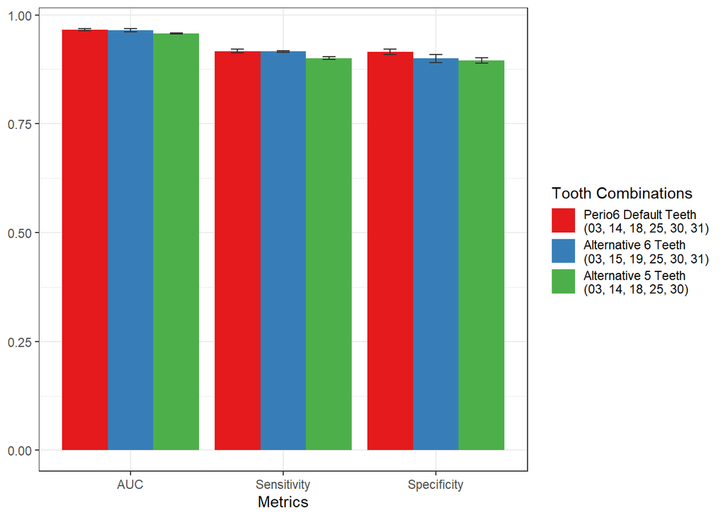

```r
alter_comb_fig <- alter_comb_df %>%
  pivot_longer(cols = c(AUC, Sensitivity, Specificity),
               values_to = "value",names_to = "metric") %>%
  mutate(tc = factor(tc, levels = names(scenarios))) %>%
  mutate(sd = case_match(metric, "AUC" ~ AUC_sd,
                         "Sensitivity" ~ Sensitivity_sd,
                         "Specificity" ~ Specificity_sd)) %>%
  ggplot(aes(x=metric, fill = tc, y = value)) +
  geom_bar(stat = "identity", position = position_dodge(width = 0.9))+
  geom_errorbar(aes(ymin = value - sd, ymax = value+sd), color = "grey20",
                position = position_dodge(width = 0.9), width = 0.25) +
  labs(x = "Metrics", fill = "Tooth Combinations") +
  theme_bw() +
  theme(axis.title.y = element_blank(),
        legend.key.spacing.y = unit(3, "point")) +
  scale_fill_brewer(palette = "Set1")
alter_comb_fig
```

```r
ggsave(filename = "../res/alternative_performance.jpeg",
       plot = alter_comb_fig, width = 5, height = 3)
ggsave(filename = "../res/alternative_performance.pdf",
       plot = alter_comb_fig, width = 5, height = 3)
```

### External Validation in ARIC Dataset (Allowing missing data and missing teeth)

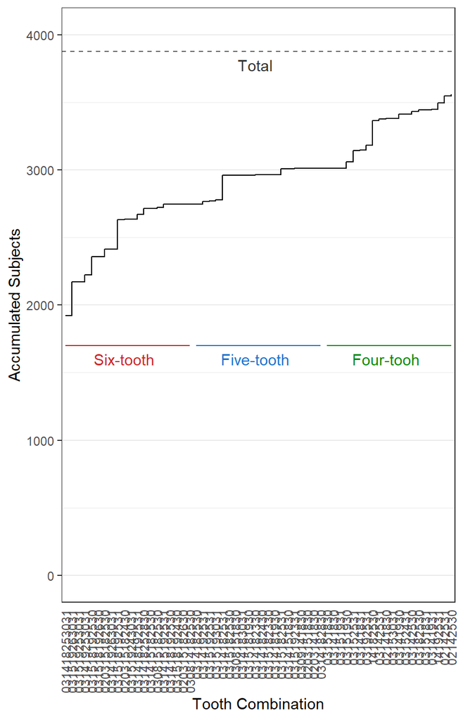

```r
test_data <- readRDS("../res/aric_extended.rds") %>%
  mutate(across(.cols = starts_with("ohx"),
                .fns = \(x) case_match(x, "0"~0, "1"~1, "2"~2, "3"~3,
                                       "4"~4, "5"~5, "6/6+"~6))) %>%
  select(seqn, starts_with("ohx"), MS) %>%
  as.data.frame()
# GenClassifier
res <- readRDS(file = "../res/aric_e.rds")
seqn_no <- readRDS(file = "../res/aric_e_seqn_no.rds")
seqn_no_len <- unlist(lapply(seqn_no, FUN = length))
seqn_no_len <- data.frame(subjects = seqn_no_len,
                          solutions = names(seqn_no_len),
                          nteeth = nchar(names(seqn_no_len))/2,
                          order = 1:length(seqn_no_len))
recover_fig <- seqn_no_len %>%
  mutate(cumsum = cumsum(subjects), group = 1) %>%
  ggplot(aes(x = fct_inorder(solutions), y = cumsum, group = group)) +
  geom_step() +
  geom_hline(yintercept = nrow(test_data), col = "grey40", linetype = "dashed") +
  geom_segment(x= 1, xend = 20, y=1700, yend=1700, color = "firebrick3")+
  geom_segment(x= 21, xend = 40, y=1700, yend=1700, color = "dodgerblue3")+
  geom_segment(x= 41, xend = 60, y=1700, yend=1700, color = "green4")+
  annotate("text", x = 30, y = nrow(test_data) - 100, label = "Total", color = "grey20") +
  annotate("text", x = 10, y = 1600, label = "Six-tooth", color = "firebrick3") +
  annotate("text", x = 30, y = 1600, label = "Five-tooth", color = "dodgerblue3") +
  annotate("text", x = 50, y = 1600, label = "Four-tooh", color = "green4") +
  theme_bw() + labs(x = "Tooth Combination", y = "Accumulated Subjects") +
  ylim(0, 4000)+
  theme(axis.text.x = element_text(angle = 90, vjust = 0.5, hjust=1),
        axis.ticks.x = element_blank(),
        panel.grid.minor.x = element_blank(),
        panel.grid.major.x = element_blank())
recover_fig
```

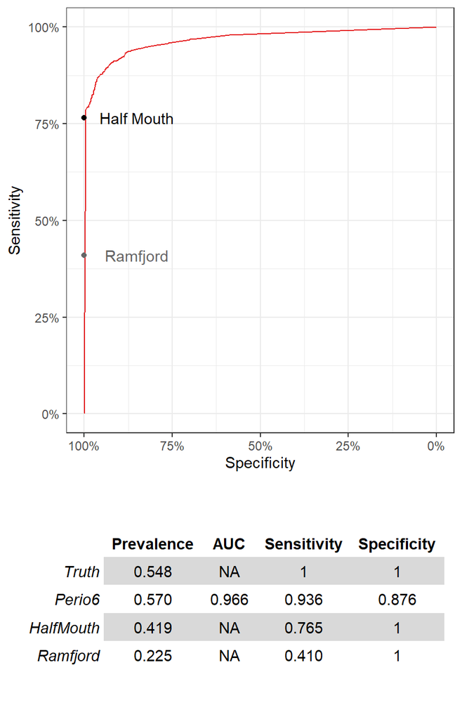

```r
ggsave(plot = recover_fig, filename = "../res/included_aric_e.jpeg",
       width = 6, height = 6)
ggsave(plot = recover_fig, filename = "../res/included_aric_e.pdf",
       width = 6, height = 6)

test_data <- test_data %>%
  filter(seqn %in% unlist(seqn_no))
stopifnot(nrow(test_data) == nrow(res))
test_data <- test_data[match(res$seqn,
                             test_data[["seqn"]]),]
stopifnot(nrow(test_data) == nrow(res))
stopifnot(res$seqn == test_data$seqn)

# simple PMEs
using = ramfjord_teeth
n_teeth <- length(unique(str_extract(using,"\\d\\d")))
temp_d <- test_data[, using]
temp_d$"seqn" <- 1:nrow(temp_d)
d <- case_def(temp_d, n_teeth_total = n_teeth) %>%
  mutate(MS = (mod_12|sev_12))
Ramfjord_pred <- as.numeric(d[["MS"]])

using = half_mouth_teeth
n_teeth <- length(unique(str_extract(using,"\\d\\d")))
temp_d <- test_data[, using]
temp_d$"seqn" <- 1:nrow(temp_d)
d <- case_def(temp_d, n_teeth_total = n_teeth) %>%
  mutate(MS = (mod_12|sev_12))
HalfMouth_pred <- as.numeric(d[["MS"]])


pred_mat <- res %>%
  as.data.frame() %>%
  mutate(Truth = test_data$MS * 1,
         Perio6 = pred_MS) %>%
  mutate(HalfMouth = HalfMouth_pred,
         Ramfjord = Ramfjord_pred) %>%
  select(Truth, Perio6, HalfMouth, Ramfjord)

metrcs_mat <- matrix(NA, nrow = ncol(pred_mat), ncol = length(metrics) + 1,
                     dimnames = list(names(pred_mat), c(metrics, "Threshold")))
for(varr in colnames(pred_mat)){
  threshold = case_match(varr, "LASSO"~0.42, "SVM" ~ 0.38, "RF"~0.40,
                         "Perio6" ~ 0.20, .default = NA_real_) # using NHANES values
  metrcs_mat[varr, ] <- calculate_metrics2(truth = pred_mat$Truth,
                                           pred = pred_mat[[varr]],
                                           threshold = threshold,
                                           specificity_thre = 0.97)
}


rocobj <- roc(formula = Truth ~ Perio6,
              data = pred_mat, quiet =TRUE)
roc_figure_arice <- ggroc(rocobj, colour = "#e41a1c")+ theme_bw() +
  annotate("point",
           y = metrcs_mat["Ramfjord", "Sensitivity"],
           x = metrcs_mat["Ramfjord", "Specificity"],
           color = "grey40")+
  annotate("text", label= "Ramfjord",
           y = metrcs_mat["Ramfjord", "Sensitivity"],
           x = metrcs_mat["Ramfjord", "Specificity"] - 0.15,
           color = "grey40")+
  annotate("point",
           y = metrcs_mat["HalfMouth", "Sensitivity"],
           x = metrcs_mat["HalfMouth", "Specificity"],
           color = "black")+
  annotate("text", label= "Half Mouth",
           y = metrcs_mat["HalfMouth", "Sensitivity"],
           x = metrcs_mat["HalfMouth", "Specificity"] - 0.15,
           color = "black")+
  # scale_color_brewer(palette = "Set1", direction = 1, name = "ML-PME Protocols")+
  labs(x = "Specificity", y = "Sensitivity")+
  scale_y_continuous(labels = scales::percent) +
  scale_x_reverse(labels = scales::percent) +
  theme(legend.position = c(0.8, 0.2))
temp_mat <- metrcs_mat[,c("Prevalence", "AUC", "Sensitivity", "Specificity")]
rownames(temp_mat) <-
  if_else(rownames(temp_mat) == "GenClassifier", "Perio6", rownames(temp_mat))
temp_mat <- apply(temp_mat, c(1,2), format_metrics)
table_plot_arice <- ggtexttable(temp_mat, theme = ttheme("lBlack"))

roc_figure_combined_arice <- ggarrange(roc_figure_arice, table_plot_arice,
                                       ncol = 1, nrow = 2,
                                       heights = c(2, 1))
roc_figure_combined_arice
```

```r
ggsave(filename = "../res/aric_e_performance.jpeg",
       plot = roc_figure_combined_arice, width = 4.5, height = 7)
ggsave(filename = "../res/aric_e_performance.pdf",
       plot = roc_figure_combined_arice, width = 4.5, height = 7)
```

### Combined figure for model performance comparison

[figure not shown]

```r
performance_combined <-
  ggarrange(
    ggarrange(
      roc_figure_nhanes+theme(plot.margin = unit(c(10, 0, 0, 0), "points")),
      roc_figure_aric+theme(plot.margin = unit(c(10, 0, 0, 0), "points")),
      roc_figure_arice+theme(plot.margin = unit(c(10, 0, 0, 0), "points")),
      ncol = 3, nrow = 1, common.legend = TRUE, legend = "bottom",
      labels = c("(a)", "(c)", "(e)")),
    ggarrange(table_plot_nhanes, table_plot_aric, table_plot_arice,
              ncol = 3, nrow = 1,
              labels = c("(b)", "(d)", "(f)")),
    nrow = 2, ncol=1, heights = c(2, 1)
  )
performance_combined
```

```r
ggsave(filename = "../res/performance_combined.jpeg",
       plot = performance_combined, width = 13, height = 7)
ggsave(filename = "../res/performance_combined.pdf",
       plot = performance_combined, width = 13, height = 7)
```

## Model Application

```r
nhanes_complete_assoc <- nhanes_complete
threshold = 0.20
train_data <- nhanes_complete %>%
  mutate(across(.cols = starts_with("ohx"),
                .fns = \(x) case_match(x, "0"~0, "1"~1, "2"~2, "3"~3,
                                       "4"~4, "5"~5, "6/6+"~6))) %>%
  select(seqn, starts_with("ohx"), MS) %>%
  as.data.frame()
tc <- c("03", "14", "18", "25", "30", "31")
tc <- str_c(prefix,
            rep(tc, each = length(suffix)),
            rep(suffix, times = length(tc)))
ramfjord_teeth <- str_c(prefix,
                        rep(Ramfjord, each = length(suffix)),
                        rep(suffix, times = length(Ramfjord)))
half_mouth_teeth <- str_c(prefix,
                          rep(half_mouth, each = length(suffix)),
                          rep(suffix, times = length(half_mouth)))
# GenClassifier
res <- readRDS(file = "../res/nhanes_6t_set1_rep0.rds")
# simple PMEs
Ramfjord_tbl <-
  prediction_models(training = train_data,
                    test = NULL,
                    using = ramfjord_teeth, method = "naive",
                    outcome = "MS", verbose = FALSE)
Half_tbl <-
  prediction_models(training = train_data,
                    test = NULL,
                    using = half_mouth_teeth, method = "naive",
                    outcome = "MS", verbose = FALSE)

nhanes_complete_assoc <- nhanes_complete_assoc %>%
  mutate(gold = MS *1,
         perio6 = (res$pred_MS >= threshold) *1,
         halfmouth = Half_tbl$pred_mat[, "naive"],
         ramfjord = Ramfjord_tbl$pred_mat[, "naive"])

model0 <- glm(gold ~ age + sex + race + smk_stt,
              data = nhanes_complete_assoc, family = binomial())
model1 <- glm(perio6 ~ age + sex + race + smk_stt,
              data = nhanes_complete_assoc, family = binomial())
model2 <- glm(halfmouth ~ age + sex + race + smk_stt,
              data = nhanes_complete_assoc, family = binomial())
model3 <- glm(ramfjord ~ age + sex + race + smk_stt,
              data = nhanes_complete_assoc, family = binomial())
extract_results <- function(model, outcome_name) {
  data.frame(
    variable = c("Age (per year)", "Sex (Male)", "Race (Hispanic)",
                 "Race (Other)", "Race (White)", "Smoking"),
    OR = exp(coef(model)[-1]),
    lower = exp(confint(model)[-1, 1]),
    upper = exp(confint(model)[-1, 2]),
    pvalue = summary(model)$coefficients[-1, 4],
    outcome = outcome_name
  )
}
results <- rbind(
  extract_results(model0, "Gold"),
  extract_results(model1, "Perio6"),
  extract_results(model2, "HalfMouth"),
  extract_results(model3, "Ramfjord")
)
```

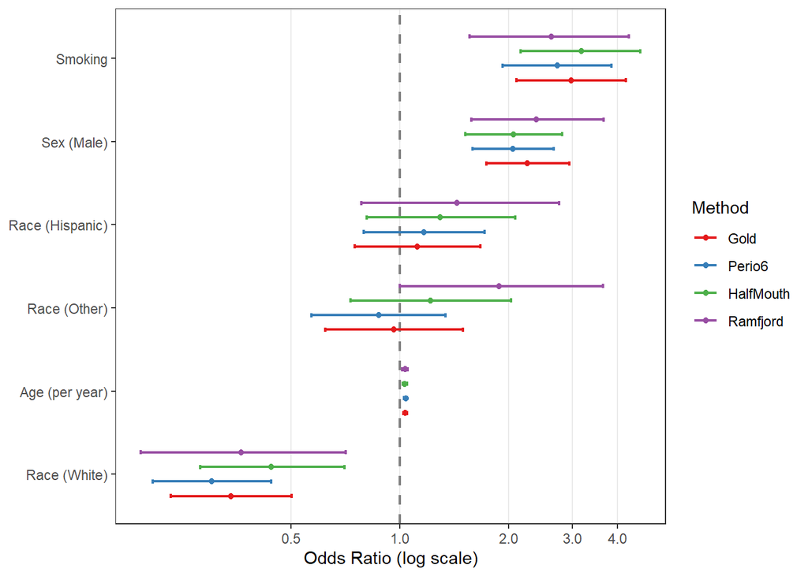

```r
results$sig <- ifelse(results$pvalue < 0.05, "*", "")

# forest plot
forest_plot <- results %>%
  mutate(outcome = factor(outcome, levels = c("Gold", "Perio6", "HalfMouth", "Ramfjord"))) %>%
  ggplot(aes(x = OR, y = reorder(variable, OR), color = outcome)) +
  geom_vline(xintercept = 1, linetype = "dashed", color = "gray50", linewidth = 0.8) +
  geom_errorbarh(aes(xmin = lower, xmax = upper), height = 0.2, linewidth = 0.8,
                 position = position_dodge(width = 0.7)) +
  geom_point(position = position_dodge(width = 0.7)) +
  scale_x_log10(breaks = c(0.5, 1, 2, 3, 4)) +
  labs(x = "Odds Ratio (log scale)",
       y = NULL) +
  scale_color_brewer(palette = "Set1", name = "Method") +
  theme_bw() +
  theme(panel.grid.major.y = element_blank(),
        panel.grid.minor = element_blank())

forest_plot
```

```r
ggsave(filename = "../res/nhanes_forest_plot.jpeg",
       plot = forest_plot, width = 5, height = 3)
ggsave(filename = "../res/nhanes_forest_plot.pdf",
       plot = forest_plot, width = 5, height = 3)
```